# Analyse des données du paludisme

- Montrer tout le code
- Cacher tout le code
- Voir les sources

Région septentrionale du Cameroun — Devoirs 1 à 4 (question par question)

Auteur·rice

A DSAMID — Formation R

Date de publication

28 avril 2026

# 1 Initialisation

```r
library(tidyverse)
library(corrplot)
library(patchwork)
library(car)
library(broom)
library(naniar)
library(scales)
library(purrr)
```

```r
paludisme <- read_csv(
  "data/base_paludisme_complete_region_septentrionale_cameroun.csv",
  show_col_types = FALSE
)
```

# 2 Devoir 1 — Débutant

## 2.1 Importation et exploration

### 2.1.1 Q1 — Importer le fichier CSV et afficher les 6 premières lignes

```r
head(paludisme)
```

| cluster_id | region | district_sanitaire | aire_sante | milieu | distance_csi_km | pluviometrie_annuelle_mm | altitude_m | menage_id | poids_menage | revenu_mensuel_fcfa | niveau_education_chef | profession_chef | taille_menage | type_habitat | acces_eau_potable | presence_latrines | nombre_moustiquaires | pulverisation_IRS | individu_id | poids_individu | age | sexe | statut_matrimonial | niveau_education | profession | grossesse | utilisation_MII | fievre_2sem | consultation_sante | … |
| --- | --- | --- | --- | --- | --- | --- | --- | --- | --- | --- | --- | --- | --- | --- | --- | --- | --- | --- | --- | --- | --- | --- | --- | --- | --- | --- | --- | --- | --- | --- |
| 1 | Extrême-Nord | District_4 | Aire_10 | Rural | 20.30882 | 937.9399 | 804.1136 | C1_M1 | 2.271404 | 54370.43 | Supérieur | Agriculteur | 4 | Terre | Oui | Oui | 1 | Non | 1 | 1.6399983 | 16 | F | Veuf | Aucun | Élève | Oui | Toujours | 0 | Oui | … |
| 1 | Extrême-Nord | District_4 | Aire_10 | Rural | 20.30882 | 937.9399 | 804.1136 | C1_M1 | 2.271404 | 54370.43 | Supérieur | Agriculteur | 4 | Terre | Oui | Oui | 1 | Non | 2 | 0.9962966 | 22 | F | Célibataire | Primaire | Commerçant | Oui | Toujours | 1 | Non | … |
| 1 | Extrême-Nord | District_4 | Aire_10 | Rural | 20.30882 | 937.9399 | 804.1136 | C1_M1 | 2.271404 | 54370.43 | Supérieur | Agriculteur | 4 | Terre | Oui | Oui | 1 | Non | 3 | 1.7543347 | 62 | F | Célibataire | Primaire | Sans emploi | Non | Toujours | 0 | Oui | … |
| 1 | Extrême-Nord | District_4 | Aire_10 | Rural | 20.30882 | 937.9399 | 804.1136 | C1_M1 | 2.271404 | 54370.43 | Supérieur | Agriculteur | 4 | Terre | Oui | Oui | 1 | Non | 4 | 2.4702048 | 10 | F | Célibataire | Primaire | Élève | Non | Parfois | 0 | Oui | … |
| 1 | Extrême-Nord | District_4 | Aire_10 | Rural | 20.30882 | 937.9399 | 804.1136 | C1_M2 | 2.450916 | 68573.40 | Supérieur | Agriculteur | 4 | Terre | Non | Oui | 2 | Oui | 5 | 1.4711755 | 30 | M | Marié | Supérieur | Élève | Non | Parfois | 0 | Non | … |
| 1 | Extrême-Nord | District_4 | Aire_10 | Rural | 20.30882 | 937.9399 | 804.1136 | C1_M2 | 2.450916 | 68573.40 | Supérieur | Agriculteur | 4 | Terre | Non | Oui | 2 | Oui | 6 | 2.0876259 | 75 | M | Divorcé | Secondaire | Agriculteur | Non | Parfois | 0 | Oui | … |

> La base est importée avec succès via `read_csv()`. Elle contient **3000** lignes et **34** colonnes. `read_csv` détecte automatiquement 14 variables numériques (`dbl`) et 20 variables texte (`chr`).

### 2.1.2 Q2 — Afficher la structure complète du data frame

```r
glimpse(paludisme)
```

```
Rows: 3,000
Columns: 34
$ cluster_id                <dbl> 1, 1, 1, 1, 1, 1, 1, 1, 1, 1, 1, 1, 1, 1, 1,…
$ region                    <chr> "Extrême-Nord", "Extrême-Nord", "Extrême-Nor…
$ district_sanitaire        <chr> "District_4", "District_4", "District_4", "D…
$ aire_sante                <chr> "Aire_10", "Aire_10", "Aire_10", "Aire_10", …
$ milieu                    <chr> "Rural", "Rural", "Rural", "Rural", "Rural",…
$ distance_csi_km           <dbl> 20.30882, 20.30882, 20.30882, 20.30882, 20.3…
$ pluviometrie_annuelle_mm  <dbl> 937.9399, 937.9399, 937.9399, 937.9399, 937.…
$ altitude_m                <dbl> 804.1136, 804.1136, 804.1136, 804.1136, 804.…
$ menage_id                 <chr> "C1_M1", "C1_M1", "C1_M1", "C1_M1", "C1_M2",…
$ poids_menage              <dbl> 2.2714038, 2.2714038, 2.2714038, 2.2714038, …
$ revenu_mensuel_fcfa       <dbl> 54370.43, 54370.43, 54370.43, 54370.43, 6857…
$ niveau_education_chef     <chr> "Supérieur", "Supérieur", "Supérieur", "Supé…
$ profession_chef           <chr> "Agriculteur", "Agriculteur", "Agriculteur",…
```

[output cut: 21 more lines]

> `glimpse()` affiche pour chaque variable : son nom, son type et un aperçu des premières valeurs. On distingue 14 variables numériques et 20 variables texte qui devront être converties en facteurs pour les analyses catégorielles.

### 2.1.3 Q3 — Dimensions de la base

```r
cat("Nombre de lignes (individus) :", nrow(paludisme), "\n")
```

```
Nombre de lignes (individus) : 3000
```

```r
cat("Nombre de colonnes (variables):", ncol(paludisme), "\n")
```

```
Nombre de colonnes (variables): 34
```

```r
cat("Dimensions complètes          :", dim(paludisme), "\n")
```

```
Dimensions complètes          : 3000 34
```

> La base contient **3000** individus et **34** variables.

### 2.1.4 Q4 — Résumé statistique des variables numériques

```r
paludisme |>
  select(where(is.numeric)) |>
  summary()
```

```
   cluster_id   distance_csi_km   pluviometrie_annuelle_mm   altitude_m
 Min.   : 1.0   Min.   : 0.5904   Min.   : 505.0           Min.   : 201.8
 1st Qu.: 8.0   1st Qu.: 6.0413   1st Qu.: 714.3           1st Qu.: 368.6
 Median :15.5   Median :13.4148   Median : 859.4           Median : 634.4
 Mean   :15.5   Mean   :12.8676   Mean   : 844.1           Mean   : 628.4
 3rd Qu.:23.0   3rd Qu.:19.3084   3rd Qu.:1011.0           3rd Qu.: 864.7
 Max.   :30.0   Max.   :24.7194   Max.   :1142.2           Max.   :1191.0
  poids_menage    revenu_mensuel_fcfa taille_menage nombre_moustiquaires
 Min.   :0.5046   Min.   : 20000      Min.   :4     Min.   :0.000
 1st Qu.:1.0256   1st Qu.: 57767      1st Qu.:4     1st Qu.:1.000
 Median :1.5407   Median : 75306      Median :4     Median :2.000
 Mean   :1.5216   Mean   : 76133      Mean   :4     Mean   :1.972
 3rd Qu.:2.0151   3rd Qu.: 94987      3rd Qu.:4     3rd Qu.:3.000
 Max.   :2.4991   Max.   :158835      Max.   :4     Max.   :7.000
  individu_id     poids_individu        age         fievre_2sem
 Min.   :   1.0   Min.   :0.5003   Min.   : 0.00   Min.   :0.000
 1st Qu.: 750.8   1st Qu.:0.9962   1st Qu.:20.00   1st Qu.:0.000
 Median :1500.5   Median :1.4823   Median :40.00   Median :0.000
 Mean   :1500.5   Mean   :1.5002   Mean   :39.83   Mean   :0.297
 3rd Qu.:2250.2   3rd Qu.:2.0122   3rd Qu.:60.00   3rd Qu.:1.000
 Max.   :3000.0   Max.   :2.4997   Max.   :79.00   Max.   :1.000
 hemoglobine_g_dl parasitemie_par_ul
 Min.   : 3.917   Min.   :   0
 1st Qu.:10.207   1st Qu.:   0
 Median :11.556   Median :   0
 Mean   :11.559   Mean   :1714
 3rd Qu.:12.920   3rd Qu.:4961
 Max.   :18.055   Max.   :5246
```

> Points d’attention : `taille_menage` = 4 pour tous les individus (constante). La médiane de `parasitemie_par_ul` = 0 (majorité TDR négatifs). `hemoglobine_g_dl` min = 3.9 g/dl (valeur critique à vérifier en Devoir 4).

### 2.1.5 Q5 — Lister les variables qualitatives

```r
vars_quali <- paludisme |> select(where(is.character)) |> names()
cat("Nombre de variables qualitatives :", length(vars_quali), "\n\n")
```

```
Nombre de variables qualitatives : 20
```

```r
paludisme |>
  select(where(is.character)) |>
  summarise(across(everything(), n_distinct)) |>
  pivot_longer(everything(), names_to = "variable", values_to = "nb_modalites") |>
  arrange(nb_modalites)
```

| variable | nb_modalites |
| --- | --- |
| milieu | 2 |
| acces_eau_potable | 2 |
| presence_latrines | 2 |
| pulverisation_IRS | 2 |
| sexe | 2 |
| grossesse | 2 |
| consultation_sante | 2 |
| test_TDR | 2 |
| hospitalisation_paludisme | 2 |
| region | 3 |

[output cut: 10 more lines]

> La base contient **20** variables qualitatives. Parmi elles, 9 sont binaires (2 modalités), 7 ont 3–4 modalités. `utilisation_MII` est **ordinale** (Jamais < Parfois < Toujours) et devra être encodée comme facteur ordonné (Q17).

## 2.2 Manipulation avec dplyr

### 2.2.1 Q6 — Sélectionner les colonnes individu_id, age, sexe, region, test_TDR, hemoglobine_g_dl

```r
df_q6 <- paludisme |>
  select(individu_id, age, sexe, region, test_TDR, hemoglobine_g_dl)
df_q6
```

| individu_id | age | sexe | region | test_TDR | hemoglobine_g_dl |
| --- | --- | --- | --- | --- | --- |
| 1 | 16 | F | Extrême-Nord | Négatif | 12.617501 |
| 2 | 22 | F | Extrême-Nord | Négatif | 8.880942 |
| 3 | 62 | F | Extrême-Nord | Négatif | 10.951238 |
| 4 | 10 | F | Extrême-Nord | Positif | 11.867729 |
| 5 | 30 | M | Extrême-Nord | Positif | 10.963664 |
| 6 | 75 | M | Extrême-Nord | Négatif | 11.366897 |
| 7 | 61 | F | Extrême-Nord | Négatif | 14.675515 |
| 8 | 67 | F | Extrême-Nord | Positif | 9.625735 |
| 9 | 49 | M | Extrême-Nord | Positif | 10.927804 |
| 10 | 57 | M | Extrême-Nord | Négatif | 9.921349 |

[output cut: 2990 more lines]

### 2.2.2 Q7 — Filtrer les individus de sexe féminin et âgés de plus de 15 ans

```r
df_q7 <- paludisme |>
  filter(sexe == "F", age > 15)
cat("Nombre d'individus (femmes > 15 ans) :", nrow(df_q7), "\n")
```

```
Nombre d'individus (femmes > 15 ans) : 1253
```

```r
df_q7 |> select(individu_id, age, sexe, region)
```

| individu_id | age | sexe | region |
| --- | --- | --- | --- |
| 1 | 16 | F | Extrême-Nord |
| 2 | 22 | F | Extrême-Nord |
| 3 | 62 | F | Extrême-Nord |
| 7 | 61 | F | Extrême-Nord |
| 8 | 67 | F | Extrême-Nord |
| 12 | 67 | F | Extrême-Nord |
| 14 | 29 | F | Extrême-Nord |
| 16 | 38 | F | Extrême-Nord |
| 18 | 26 | F | Extrême-Nord |
| 19 | 48 | F | Extrême-Nord |

[output cut: 1243 more lines]

> **1253** femmes de plus de 15 ans sur 3 000 individus.

### 2.2.3 Q8 — Créer la variable categorie_age

```r
paludisme <- paludisme |>
  mutate(categorie_age = case_when(
    age <  5              ~ "enfant",
    age >= 5  & age <= 14 ~ "jeune",
    age >= 15 & age <= 49 ~ "adulte",
    age >= 50             ~ "senior"
  ))

paludisme |> count(categorie_age)
```

| categorie_age | n |
| --- | --- |
| adulte | 1309 |
| enfant | 184 |
| jeune | 354 |
| senior | 1153 |

### 2.2.4 Q9 — Renommer test_TDR en resultat_tdr

```r
paludisme <- paludisme |>
  rename(resultat_tdr = test_TDR)

cat("Vérification — la colonne s'appelle désormais :",
    "resultat_tdr" %in% names(paludisme), "\n")
```

```
Vérification — la colonne s'appelle désormais : TRUE
```

```r
cat("L'ancienne colonne test_TDR existe encore :",
    "test_TDR" %in% names(paludisme), "\n")
```

```
L'ancienne colonne test_TDR existe encore : FALSE
```

### 2.2.5 Q10 — Trier par âge décroissant, puis par région alphabétique

```r
df_q10 <- paludisme |>
  arrange(desc(age), region)
df_q10 |> select(individu_id, age, region)
```

| individu_id | age | region |
| --- | --- | --- |
| 214 | 79 | Adamaoua |
| 223 | 79 | Adamaoua |
| 254 | 79 | Adamaoua |
| 277 | 79 | Adamaoua |
| 373 | 79 | Adamaoua |
| 374 | 79 | Adamaoua |
| 415 | 79 | Adamaoua |
| 416 | 79 | Adamaoua |
| 420 | 79 | Adamaoua |
| 458 | 79 | Adamaoua |

[output cut: 2990 more lines]

## 2.3 Résumés et groupements

### 2.3.1 Q11 — Nombre total d’individus par région

```r
paludisme |> count(region, name = "nb_individus")
```

| region | nb_individus |
| --- | --- |
| Adamaoua | 1200 |
| Extrême-Nord | 1300 |
| Nord | 500 |

### 2.3.2 Q12 — Nombre d’hommes et de femmes dans chaque région

```r
paludisme |> count(region, sexe, name = "nb_individus")
```

| region | sexe | nb_individus |
| --- | --- | --- |
| Adamaoua | F | 628 |
| Adamaoua | M | 572 |
| Extrême-Nord | F | 656 |
| Extrême-Nord | M | 644 |
| Nord | F | 264 |
| Nord | M | 236 |

### 2.3.3 Q13 — Âge moyen et écart-type par sexe

```r
paludisme |>
  group_by(sexe) |>
  summarise(
    age_moyen  = round(mean(age, na.rm = TRUE), 1),
    ecart_type = round(sd(age,   na.rm = TRUE), 1),
    n          = n()
  )
```

| sexe | age_moyen | ecart_type | n |
| --- | --- | --- | --- |
| F | 40.3 | 23.3 | 1548 |
| M | 39.3 | 22.7 | 1452 |

### 2.3.4 Q14 — Revenu mensuel moyen par milieu (rural/urbain)

```r
paludisme |>
  group_by(milieu) |>
  summarise(
    revenu_moyen = round(mean(revenu_mensuel_fcfa, na.rm = TRUE)),
    n            = n()
  )
```

| milieu | revenu_moyen | n |
| --- | --- | --- |
| Rural | 76036 | 2600 |
| Urbain | 76769 | 400 |

### 2.3.5 Q15 — Min, max et moyenne de la pluviométrie par région

```r
paludisme |>
  group_by(region) |>
  summarise(
    pluie_min = round(min(pluviometrie_annuelle_mm)),
    pluie_moy = round(mean(pluviometrie_annuelle_mm)),
    pluie_max = round(max(pluviometrie_annuelle_mm))
  )
```

| region | pluie_min | pluie_moy | pluie_max |
| --- | --- | --- | --- |
| Adamaoua | 505 | 777 | 1121 |
| Extrême-Nord | 674 | 892 | 1142 |
| Nord | 584 | 879 | 1087 |

## 2.4 Création de variables et recodage

### 2.4.1 Q16 — Variable binaire pauvre (revenu < 50 000 FCFA)

```r
paludisme <- paludisme |>
  mutate(pauvre = if_else(revenu_mensuel_fcfa < 50000, "Oui", "Non"))
paludisme |> count(pauvre) |> mutate(pct = round(n / sum(n) * 100, 1))
```

| pauvre | n | pct |
| --- | --- | --- |
| Non | 2464 | 82.1 |
| Oui | 536 | 17.9 |

### 2.4.2 Q17 — Transformer utilisation_MII en facteur ordonné

```r
paludisme <- paludisme |>
  mutate(utilisation_MII = factor(utilisation_MII,
                                  levels  = c("Jamais", "Parfois", "Toujours"),
                                  ordered = TRUE))
cat("Classe :", class(paludisme$utilisation_MII), "\n")
```

```
Classe : ordered factor
```

```r
cat("Niveaux :", levels(paludisme$utilisation_MII), "\n")
```

```
Niveaux : Jamais Parfois Toujours
```

```r
paludisme |> count(utilisation_MII)
```

| utilisation_MII | n |
| --- | --- |
| Jamais | 637 |
| Parfois | 890 |
| Toujours | 1473 |

### 2.4.3 Q18 — Variable anemie (hémoglobine < 11 g/dl)

```r
paludisme <- paludisme |>
  mutate(anemie = if_else(hemoglobine_g_dl < 11, "Oui", "Non"))
paludisme |> count(anemie) |> mutate(pct = round(n / sum(n) * 100, 1))
```

| anemie | n | pct |
| --- | --- | --- |
| Non | 1822 | 60.7 |
| Oui | 1178 | 39.3 |

### 2.4.4 Q19 — Variable charge_parasitaire

```r
paludisme <- paludisme |>
  mutate(charge_parasitaire = case_when(
    parasitemie_par_ul == 0    ~ "Négatif",
    parasitemie_par_ul <= 5000 ~ "Faible",
    parasitemie_par_ul >  5000 ~ "Élevée"
  ))
paludisme |> count(charge_parasitaire)
```

| charge_parasitaire | n |
| --- | --- |
| Faible | 515 |
| Négatif | 1972 |
| Élevée | 513 |

### 2.4.5 Q20 — Extraire le premier mot de profession → prof_simple

```r
paludisme <- paludisme |>
  mutate(prof_simple = word(profession, 1))
paludisme |> count(prof_simple, sort = TRUE)
```

| prof_simple | n |
| --- | --- |
| Élève | 772 |
| Agriculteur | 754 |
| Commerçant | 745 |
| Sans | 729 |

## 2.5 Graphiques simples avec ggplot2

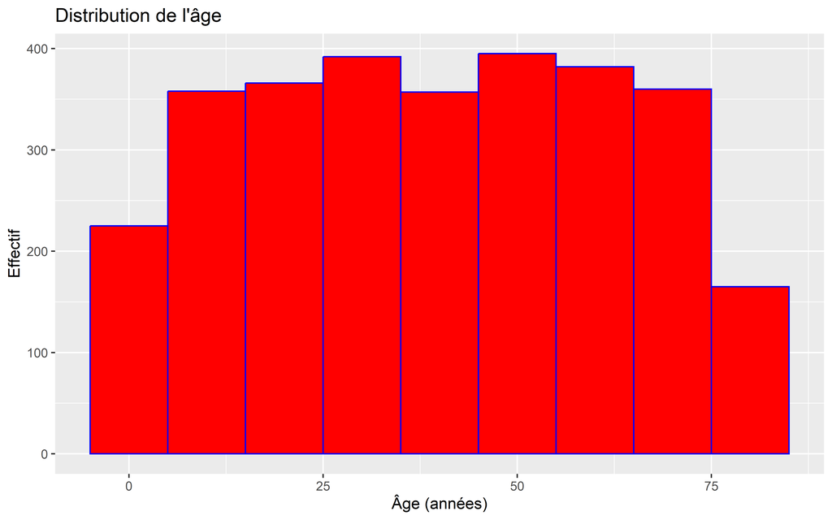

```r
ggplot(paludisme, aes(x = age)) +
  geom_histogram(binwidth = 10, color="blue", fill="red") +
  labs(title = "Distribution de l'âge", x = "Âge (années)", y = "Effectif")
```

### 2.5.2 Q22 — Diagramme en barres de la variable region

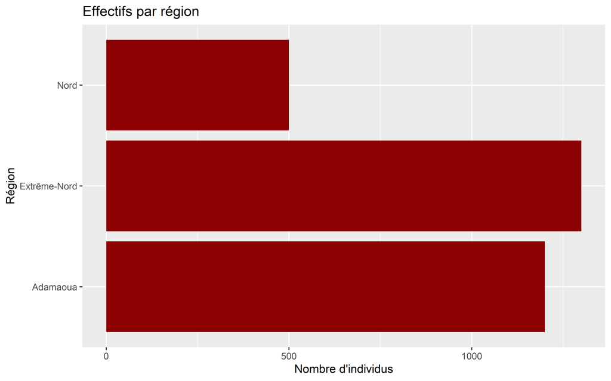

Figure 2: Q22 — Effectifs par région

```r
ggplot(paludisme, aes(y = region)) +
  geom_bar(fill="darkred") +
  labs(title = "Effectifs par région", y = "Région", x = "Nombre d'individus")
```

### 2.5.3 Q23 — Boxplot de l’hémoglobine en fonction du sexe

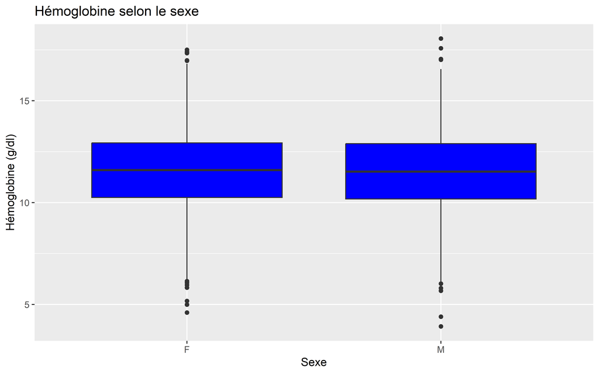

Figure 3: Q23 — Hémoglobine selon le sexe

```r
ggplot(paludisme, aes(x = sexe, y = hemoglobine_g_dl)) +
  geom_boxplot(fill="blue") +
  labs(title = "Hémoglobine selon le sexe", x = "Sexe", y = "Hémoglobine (g/dl)")
```

### 2.5.4 Q24 — Nuage de points âge ~ hémoglobine coloré par sexe

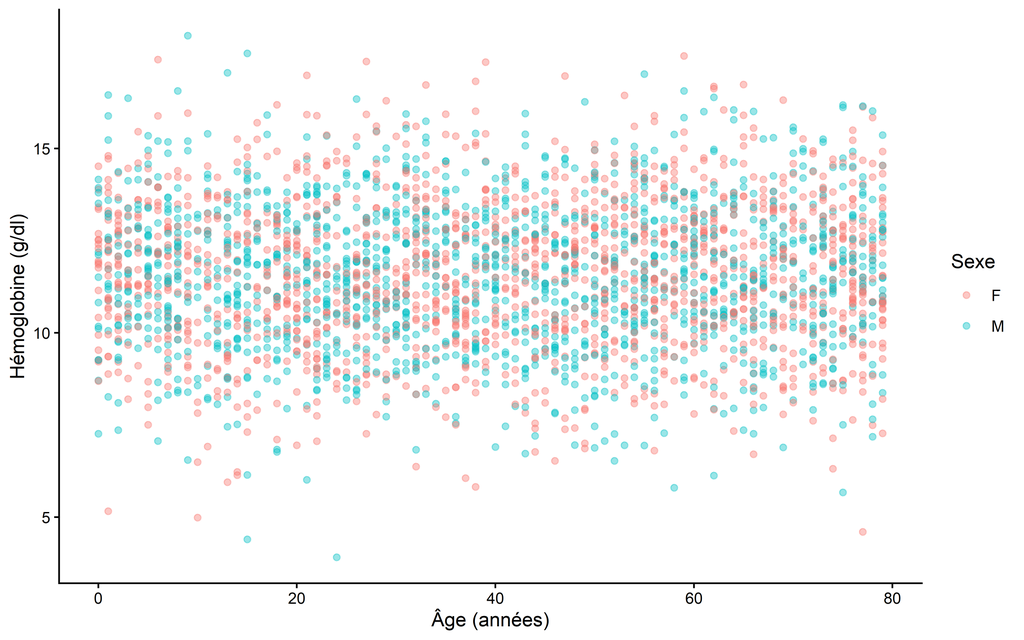

Figure 4: Q24 — Nuage de points âge vs hémoglobine (coloré par sexe)

```r
ggplot(paludisme, aes(x = age, y = hemoglobine_g_dl, color = sexe)) +
  geom_point(alpha = 0.4) +
  labs(x = "Âge (années)", y = "Hémoglobine (g/dl)", color = "Sexe")+
  theme_classic()
```

### 2.5.5 Q25 — Ajouter un titre et des étiquettes au graphique Q24

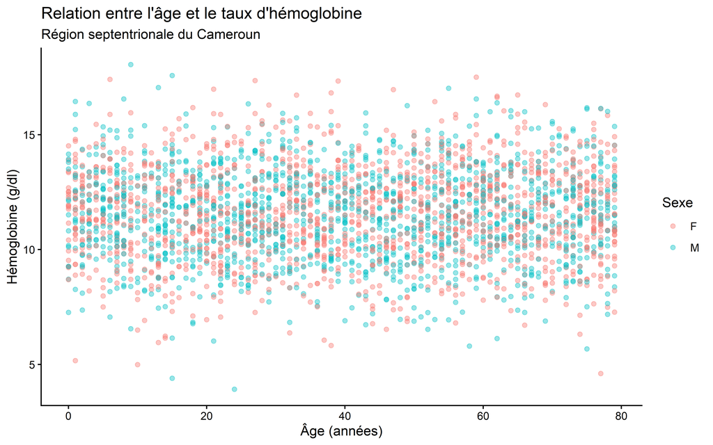

Figure 5: Q25 — Nuage de points âge vs hémoglobine avec titre et axes étiquetés

```r
ggplot(paludisme, aes(x = age, y = hemoglobine_g_dl, color = sexe)) +
  geom_point(alpha = 0.4) +
  labs(
    title    = "Relation entre l'âge et le taux d'hémoglobine",
    subtitle = "Région septentrionale du Cameroun",
    x        = "Âge (années)",
    y        = "Hémoglobine (g/dl)",
    color    = "Sexe"
  )+
  theme_classic()
```

## 2.6 Statistiques descriptives de base

### 2.6.1 Q26 — Proportion de tests TDR positifs

```r
paludisme |>
  summarise(
    n_total      = n(),
    n_positif    = sum(resultat_tdr == "Positif"),
    prop_positif = round(mean(resultat_tdr == "Positif") * 100, 1)
  )
```

| n_total | n_positif | prop_positif |
| --- | --- | --- |
| 3000 | 1028 | 34.3 |

> **34.3%** des tests TDR sont positifs.

### 2.6.2 Q27 — Prévalence du paludisme par région (%)

```r
paludisme |>
  group_by(region) |>
  summarise(
    n_total        = n(),
    n_positif      = sum(resultat_tdr == "Positif"),
    prevalence_pct = round(mean(resultat_tdr == "Positif") * 100, 1)
  )
```

| region | n_total | n_positif | prevalence_pct |
| --- | --- | --- | --- |
| Adamaoua | 1200 | 389 | 32.4 |
| Extrême-Nord | 1300 | 456 | 35.1 |
| Nord | 500 | 183 | 36.6 |

### 2.6.3 Q28 — Hémoglobine moyenne : femmes enceintes vs non enceintes

```r
paludisme |>
  filter(sexe == "F") |>
  group_by(grossesse) |>
  summarise(
    n              = n(),
    hb_moyenne     = round(mean(hemoglobine_g_dl, na.rm = TRUE), 2),
    hb_ecart_type  = round(sd(hemoglobine_g_dl,   na.rm = TRUE), 2)
  )
```

| grossesse | n | hb_moyenne | hb_ecart_type |
| --- | --- | --- | --- |
| Non | 1219 | 11.64 | 1.98 |
| Oui | 329 | 11.41 | 2.03 |

### 2.6.4 Q29 — Pourcentage d’individus ayant eu de la fièvre (2 dernières semaines)

```r
paludisme |>
  summarise(
    n_total    = n(),
    n_fievre   = sum(fievre_2sem == 1),
    pct_fievre = round(mean(fievre_2sem == 1) * 100, 1)
  )
```

| n_total | n_fievre | pct_fievre |
| --- | --- | --- |
| 3000 | 891 | 29.7 |

> **29.7%** des individus ont eu de la fièvre dans les deux dernières semaines.

### 2.6.5 Q30 — Ménages avec au moins une moustiquaire

```r
paludisme |>
  distinct(menage_id, .keep_all = TRUE) |>
  summarise(
    n_menages_total       = n(),
    n_avec_moustiquaire   = sum(nombre_moustiquaires >= 1),
    pct_avec_moustiquaire = round(mean(nombre_moustiquaires >= 1) * 100, 1)
  )
```

| n_menages_total | n_avec_moustiquaire | pct_avec_moustiquaire |
| --- | --- | --- |
| 750 | 649 | 86.5 |

> Sur 750 ménages distincts, **86.5%** possèdent au moins une moustiquaire.

# 3 Devoir 2 — Intermédiaire

## 3.1 Manipulations avancées avec dplyr

### 3.1.1 Q1 — Moustiquaires par personne par ménage

```r
menage_stats <- paludisme |>
  group_by(menage_id) |>
  summarise(
    nb_individus               = n(),
    nb_moustiquaires           = first(nombre_moustiquaires),
    moustiquaires_par_personne = nb_moustiquaires / nb_individus
  )
menage_stats
```

| menage_id | nb_individus | nb_moustiquaires | moustiquaires_par_personne |
| --- | --- | --- | --- |
| C10_M1 | 4 | 1 | 0.25 |
| C10_M10 | 4 | 3 | 0.75 |
| C10_M11 | 4 | 1 | 0.25 |
| C10_M12 | 4 | 2 | 0.50 |
| C10_M13 | 4 | 1 | 0.25 |
| C10_M14 | 4 | 2 | 0.50 |
| C10_M15 | 4 | 2 | 0.50 |
| C10_M16 | 4 | 0 | 0.00 |
| C10_M17 | 4 | 5 | 1.25 |
| C10_M18 | 4 | 1 | 0.25 |

[output cut: 740 more lines]

### 3.1.2 Q2 — Top 5 ménages avec le revenu le plus élevé

```r
paludisme |>
  distinct(menage_id, revenu_mensuel_fcfa) |>
  slice_max(revenu_mensuel_fcfa, n = 5) |>
  arrange(desc(revenu_mensuel_fcfa))
```

| menage_id | revenu_mensuel_fcfa |
| --- | --- |
| C23_M11 | 158834.8 |
| C5_M23 | 151412.5 |
| C26_M1 | 150480.4 |
| C2_M18 | 149383.6 |
| C19_M7 | 146225.2 |

### 3.1.3 Q3 — Résumé par district sanitaire (cas positifs, âge moyen, proportion enceintes)

```r
paludisme |>
  filter(resultat_tdr == "Positif") |>
  group_by(district_sanitaire) |>
  summarise(
    n_positifs         = n(),
    age_moyen_positifs = round(mean(age, na.rm = TRUE), 1),
    prop_enceintes_pct = round(mean(grossesse == "Oui", na.rm = TRUE) * 100, 1)
  ) |>
  arrange(desc(n_positifs))
```

| district_sanitaire | n_positifs | age_moyen_positifs | prop_enceintes_pct |
| --- | --- | --- | --- |
| District_2 | 316 | 41.2 | 10.1 |
| District_4 | 164 | 39.2 | 9.8 |
| District_5 | 156 | 38.9 | 10.3 |
| District_1 | 146 | 40.0 | 11.0 |
| District_7 | 105 | 39.8 | 12.4 |
| District_6 | 74 | 38.1 | 10.8 |
| District_3 | 67 | 38.7 | 9.0 |

### 3.1.4 Q4 — Colonne quartile_revenu avec ntile()

```r
paludisme <- paludisme |>
  mutate(quartile_revenu = ntile(revenu_mensuel_fcfa, 4))

paludisme |>
  group_by(quartile_revenu) |>
  summarise(
    revenu_min = round(min(revenu_mensuel_fcfa)),
    revenu_max = round(max(revenu_mensuel_fcfa)),
    n          = n()
  )
```

| quartile_revenu | revenu_min | revenu_max | n |
| --- | --- | --- | --- |
| 1 | 20000 | 57767 | 750 |
| 2 | 57767 | 75252 | 750 |
| 3 | 75360 | 94987 | 750 |
| 4 | 94987 | 158835 | 750 |

### 3.1.5 Q5 — Distance moyenne ± écart-type au CSI par milieu + graphique

```r
dist_milieu <- paludisme |>
  group_by(milieu) |>
  summarise(
    moy_dist = mean(distance_csi_km, na.rm = TRUE),
    sd_dist  = sd(distance_csi_km,   na.rm = TRUE)
  )
dist_milieu
```

| milieu | moy_dist | sd_dist |
| --- | --- | --- |
| Rural | 12.23919 | 7.972334 |
| Urbain | 16.95197 | 5.604798 |

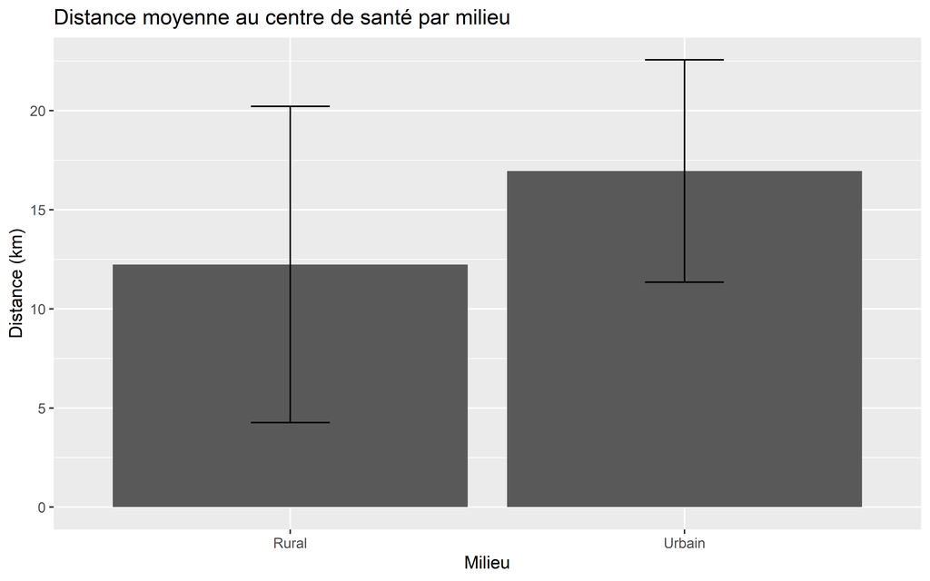

Figure 6: Q5 — Distance moyenne au CSI par milieu avec barres d’erreur (± écart-type)

```r
ggplot(dist_milieu, aes(x = milieu, y = moy_dist)) +
  geom_col() +
  geom_errorbar(aes(ymin = moy_dist - sd_dist, ymax = moy_dist + sd_dist), width = 0.2) +
  labs(title = "Distance moyenne au centre de santé par milieu",
       x = "Milieu", y = "Distance (km)")
```

## 3.2 Transformations avec tidyr

### 3.2.1 Q6 — Tableau croisé region × milieu en format large

```r
tab_long <- paludisme |>
  count(region, milieu, name = "nb_individus")

tab_large <- tab_long |>
  pivot_wider(names_from = milieu, values_from = nb_individus, values_fill = 0)

cat("Format long :\n"); print(tab_long)
```

```
Format long :
```

```
# A tibble: 6 × 3
  region       milieu nb_individus
  <chr>        <chr>         <int>
1 Adamaoua     Rural          1100
2 Adamaoua     Urbain          100
3 Extrême-Nord Rural          1200
4 Extrême-Nord Urbain          100
5 Nord         Rural           300
6 Nord         Urbain          200
```

```r
cat("\nFormat large :\n"); print(tab_large)
```

```
Format large :
```

```
# A tibble: 3 × 3
  region       Rural Urbain
  <chr>        <int>  <int>
1 Adamaoua      1100    100
2 Extrême-Nord  1200    100
3 Nord           300    200
```

### 3.2.2 Q7 — Revenir au format long avec pivot_longer

```r
tab_large |>
  pivot_longer(cols = c(Rural, Urbain),
               names_to  = "milieu",
               values_to = "nb_individus")
```

| region | milieu | nb_individus |
| --- | --- | --- |
| Adamaoua | Rural | 1100 |
| Adamaoua | Urbain | 100 |
| Extrême-Nord | Rural | 1200 |
| Extrême-Nord | Urbain | 100 |
| Nord | Rural | 300 |
| Nord | Urbain | 200 |

### 3.2.3 Q8 — Tableau region × classe d’âge en format large

```r
paludisme |>
  count(region, categorie_age, name = "nb_individus") |>
  pivot_wider(names_from = categorie_age, values_from = nb_individus, values_fill = 0)
```

| region | adulte | enfant | jeune | senior |
| --- | --- | --- | --- | --- |
| Adamaoua | 534 | 76 | 141 | 449 |
| Extrême-Nord | 554 | 81 | 157 | 508 |
| Nord | 221 | 27 | 56 | 196 |

### 3.2.4 Q9 — Séparer menage_id en colonnes cluster et menage

```r
paludisme |>
  select(menage_id) |>
  distinct() |>
  separate(menage_id, into = c("cluster", "menage"), sep = "_") |>
  head(10)
```

| cluster | menage |
| --- | --- |
| C1 | M1 |
| C1 | M2 |
| C1 | M3 |
| C1 | M4 |
| C1 | M5 |
| C1 | M6 |
| C1 | M7 |
| C1 | M8 |
| C1 | M9 |
| C1 | M10 |

### 3.2.5 Q10 — Fusionner données individuelles avec résumé par ménage

```r
resume_menage <- paludisme |>
  group_by(menage_id) |>
  summarise(revenu_moyen_calcule = mean(revenu_mensuel_fcfa))

verif <- paludisme |>
  select(individu_id, menage_id, revenu_mensuel_fcfa) |>
  left_join(resume_menage, by = "menage_id") |>
  mutate(coherent = near(revenu_mensuel_fcfa, revenu_moyen_calcule))

cat("Lignes incohérentes :", sum(!verif$coherent), "\n")
```

```
Lignes incohérentes : 0
```

```r
cat("→ Tous les individus d'un même ménage ont exactement le même revenu.\n")
```

```
→ Tous les individus d'un même ménage ont exactement le même revenu.
```

## 3.3 Graphiques élaborés

### 3.3.1 Q11 — Barres groupées : cas positifs/négatifs par région

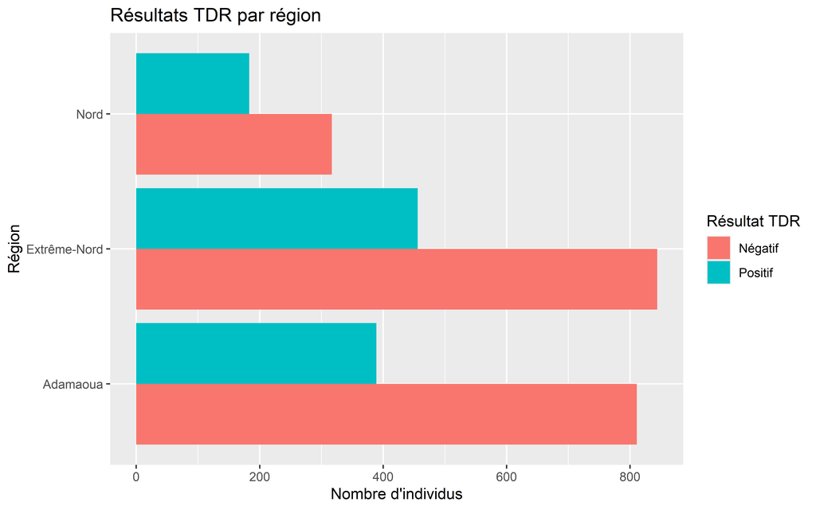

Figure 7: Q11 — Résultats TDR par région (barres groupées)

```r
ggplot(paludisme, aes(y = region, fill = resultat_tdr)) +
  geom_bar(position = "dodge") +
  labs(title = "Résultats TDR par région",
       y = "Région", x = "Nombre d'individus", fill = "Résultat TDR")
```

### 3.3.2 Q12 — Ajouter des étiquettes de valeur sur les barres

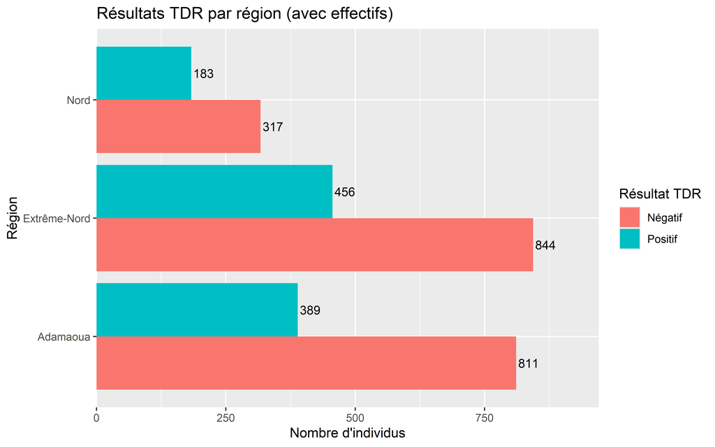

Figure 8: Q12 — Résultats TDR par région avec étiquettes

```r
tdr_region <- paludisme |> count(region, resultat_tdr, name = "n")

ggplot(tdr_region, aes(y = region, x = n, fill = resultat_tdr)) +
  geom_col(position = "dodge") +
  geom_text(aes(label = n),
            position = position_dodge(width = 0.9),
            hjust = -0.1, size = 3.5) +
  scale_x_continuous(expand = expansion(mult = c(0, 0.15))) +
  labs(title = "Résultats TDR par région (avec effectifs)",
       y = "Région", x = "Nombre d'individus", fill = "Résultat TDR")
```

### 3.3.3 Q13 — Boxplot hémoglobine ~ catégorie d’âge, coloré par sexe

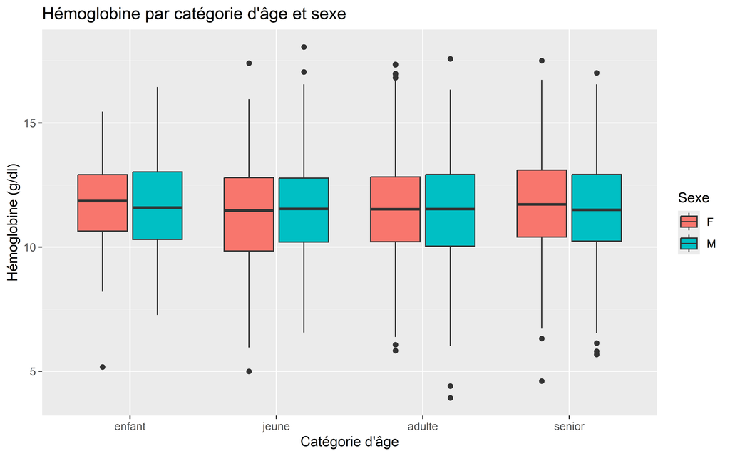

Figure 9: Q13 — Hémoglobine par catégorie d’âge et sexe

```r
paludisme <- paludisme |>
  mutate(categorie_age = factor(categorie_age,
                                levels = c("enfant","jeune","adulte","senior")))

ggplot(paludisme, aes(x = categorie_age, y = hemoglobine_g_dl, fill = sexe)) +
  geom_boxplot() +
  labs(title = "Hémoglobine par catégorie d'âge et sexe",
       x = "Catégorie d'âge", y = "Hémoglobine (g/dl)", fill = "Sexe")
```

### 3.3.4 Q14 — Histogramme superposé âge : positifs vs négatifs (transparence)

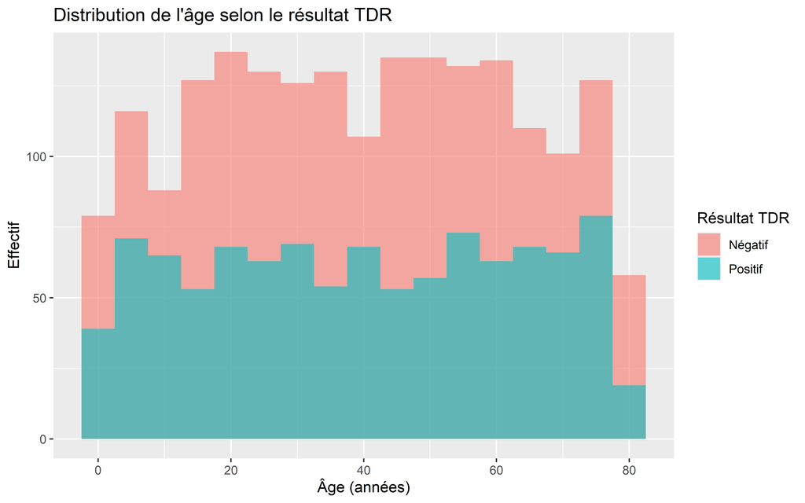

Figure 10: Q14 — Distribution de l’âge selon le résultat TDR (histogrammes superposés)

```r
ggplot(paludisme, aes(x = age, fill = resultat_tdr)) +
  geom_histogram(binwidth = 5, alpha = 0.6, position = "identity") +
  labs(title = "Distribution de l'âge selon le résultat TDR",
       x = "Âge (années)", y = "Effectif", fill = "Résultat TDR")
```

### 3.3.5 Q15 — Matrice de corrélation graphique

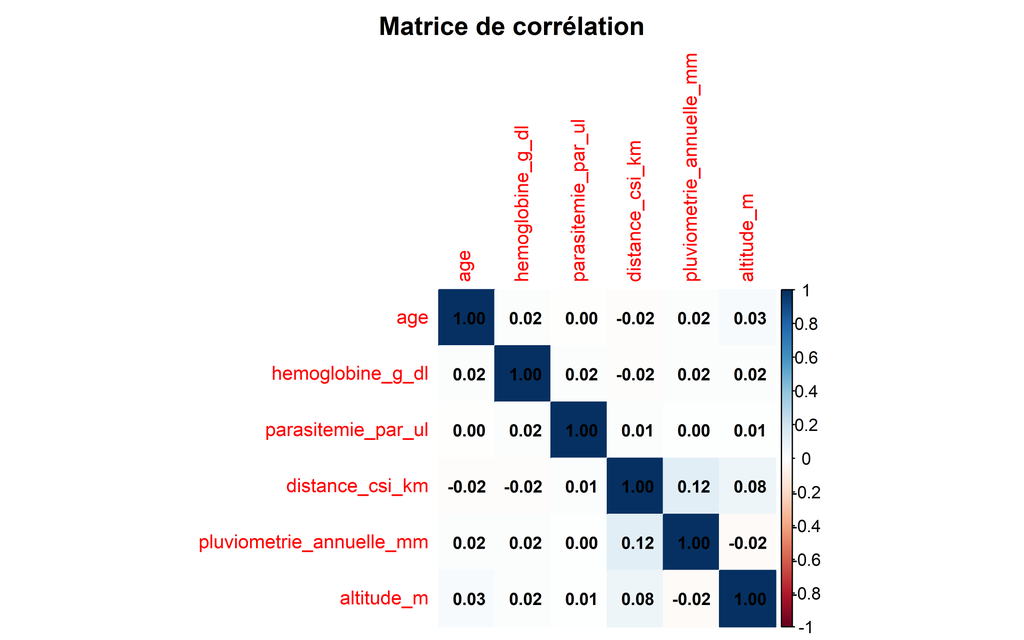

Figure 11: Q15 — Matrice de corrélation des variables numériques clés

```r
cor_data <- paludisme |>
  select(age, hemoglobine_g_dl, parasitemie_par_ul,
         distance_csi_km, pluviometrie_annuelle_mm, altitude_m)
mat_cor <- cor(cor_data, use = "complete.obs")

corrplot(mat_cor, method = "color", addCoef.col = "black",
         number.cex = 0.8, tl.cex = 0.9,
         title = "Matrice de corrélation", mar = c(0, 0, 2, 0))
```

> Toutes les corrélations sont proches de 0 — aucune colinéarité notable entre ces variables.

### 3.3.6 Q16 — facet_wrap : distribution de l’hémoglobine par région

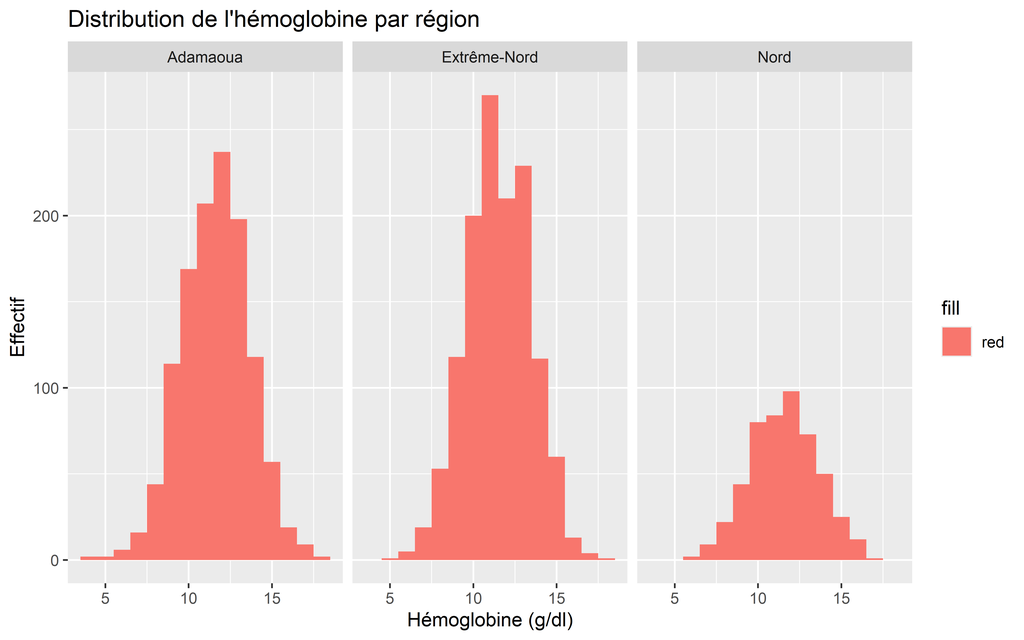

Figure 12: Q16 — Distribution de l’hémoglobine par région (facettes)

```r
ggplot(paludisme, aes(x = hemoglobine_g_dl, fill="red")) +
  geom_histogram(binwidth = 1) +
  facet_wrap(~ region) +
  labs(title = "Distribution de l'hémoglobine par région",
       x = "Hémoglobine (g/dl)", y = "Effectif")
```

### 3.3.7 Q17 — Graphique en violon : parasitémie selon le résultat TDR

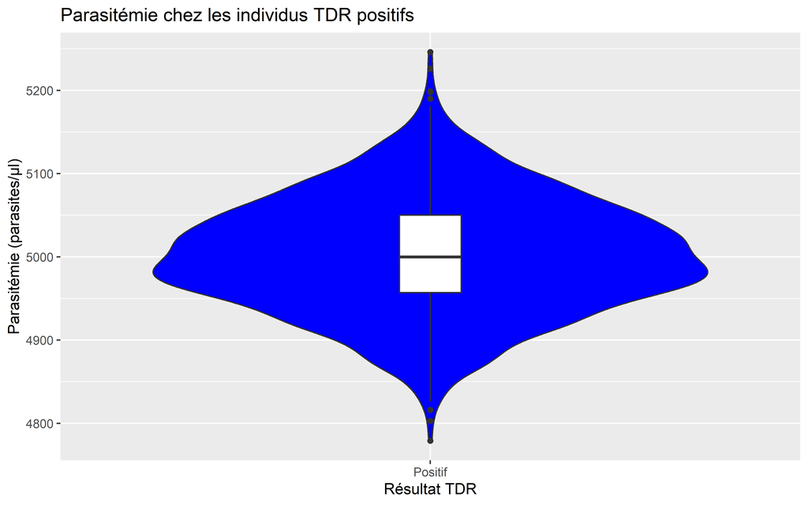

Figure 13: Q17 — Distribution de la parasitémie chez les TDR positifs (violon + boxplot)

```r
paludisme |>
  filter(resultat_tdr == "Positif") |>
  ggplot(aes(x = resultat_tdr, y = parasitemie_par_ul)) +
  geom_violin(fill="blue") +
  geom_boxplot(width = 0.1) +
  labs(title = "Parasitémie chez les individus TDR positifs",
       x = "Résultat TDR", y = "Parasitémie (parasites/µl)")
```

### 3.3.8 Q18 — geom_smooth (lm) sur âge ~ hémoglobine, séparé par sexe

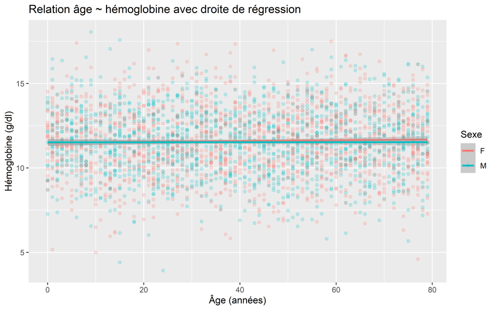

Figure 14: Q18 — Régression linéaire âge ~ hémoglobine par sexe

```r
ggplot(paludisme, aes(x = age, y = hemoglobine_g_dl, color = sexe)) +
  geom_point(alpha = 0.2) +
  geom_smooth(method = "lm", se = TRUE) +
  labs(title = "Relation âge ~ hémoglobine avec droite de régression",
       x = "Âge (années)", y = "Hémoglobine (g/dl)", color = "Sexe")
```

### 3.3.9 Q19 — Proportion TDR positifs par classe d’âge avec IC binomial

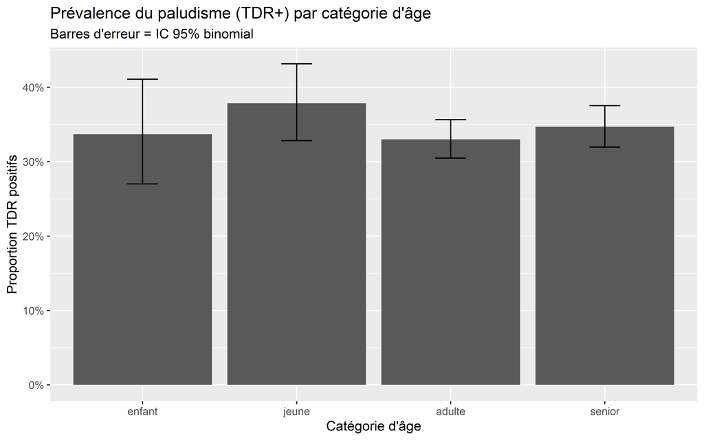

Figure 15: Q19 — Prévalence du paludisme par catégorie d’âge (IC 95% binomial)

```r
prev_age <- paludisme |>
  group_by(categorie_age) |>
  summarise(
    n       = n(),
    n_pos   = sum(resultat_tdr == "Positif"),
    prop    = n_pos / n,
    ic_low  = prop.test(n_pos, n)$conf.int[1],
    ic_high = prop.test(n_pos, n)$conf.int[2]
  )

ggplot(prev_age, aes(x = categorie_age, y = prop)) +
  geom_col() +
  geom_errorbar(aes(ymin = ic_low, ymax = ic_high), width = 0.2) +
  scale_y_continuous(labels = percent_format()) +
  labs(title   = "Prévalence du paludisme (TDR+) par catégorie d'âge",
       subtitle = "Barres d'erreur = IC 95% binomial",
       x = "Catégorie d'âge", y = "Proportion TDR positifs")
```

### 3.3.10 Q20 — Sauvegarder le graphique en PNG (300 dpi)

```r
ggsave("data/prevalence_par_age_TDR.png", width = 8, height = 6, dpi = 300)
cat("Graphique sauvegardé : data/prevalence_par_age_TDR.png\n")
```

```
Graphique sauvegardé : data/prevalence_par_age_TDR.png
```

## 3.4 Tests statistiques simples

### 3.4.1 Q21 — Chi² : sexe ~ résultat TDR (avec vérification des effectifs théoriques)

```r
tab_chi2 <- table(paludisme$sexe, paludisme$resultat_tdr)
cat("Effectifs observés :\n"); print(tab_chi2)
```

```
Effectifs observés :
```

```
    Négatif Positif
  F    1026     522
  M     946     506
```

```r
cat("\nEffectifs théoriques :\n"); print(chisq.test(tab_chi2)$expected)
```

```
Effectifs théoriques :
```

```
     Négatif Positif
  F 1017.552 530.448
  M  954.448 497.552
```

```r
cat("\nTest du Chi² :\n"); print(chisq.test(tab_chi2))
```

```
Test du Chi² :
```

```
    Pearson's Chi-squared test with Yates' continuity correction

data:  tab_chi2
X-squared = 0.37432, df = 1, p-value = 0.5407
```

> Tous les effectifs théoriques > 5 → conditions satisfaites. p = 0.54 → **pas d’association** entre le sexe et le résultat TDR.

### 3.4.2 Q22 — Comparer l’âge selon la fièvre (Shapiro + QQ-plot + Wilcoxon)

```r
age_fievre <- paludisme$age[paludisme$fievre_2sem == 1]
age_sans   <- paludisme$age[paludisme$fievre_2sem == 0]
set.seed(4821)
cat("Shapiro — groupe avec fièvre :\n")
```

```
Shapiro — groupe avec fièvre :
```

```r
print(shapiro.test(sample(age_fievre, min(length(age_fievre), 5000))))
```

```
    Shapiro-Wilk normality test

data:  sample(age_fievre, min(length(age_fievre), 5000))
W = 0.95316, p-value = 3.087e-16
```

```r
cat("\nShapiro — groupe sans fièvre :\n")
```

```
Shapiro — groupe sans fièvre :
```

```r
print(shapiro.test(sample(age_sans, min(length(age_sans), 5000))))
```

```
    Shapiro-Wilk normality test

data:  sample(age_sans, min(length(age_sans), 5000))
W = 0.95672, p-value < 2.2e-16
```

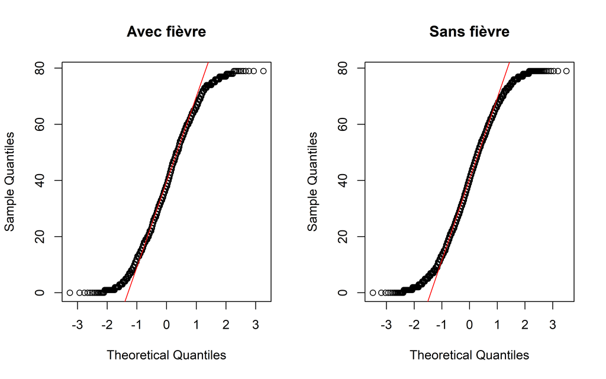

Figure 16: Q22 — QQ-plots de l’âge selon la présence de fièvre

```r
par(mfrow = c(1, 2))
qqnorm(age_fievre, main = "Avec fièvre"); qqline(age_fievre, col = "red")
qqnorm(age_sans,   main = "Sans fièvre"); qqline(age_sans,   col = "red")
par(mfrow = c(1, 1))
```

```r
cat("Normalité rejetée (p << 0.05) → Test de Wilcoxon :\n")
```

```
Normalité rejetée (p << 0.05) → Test de Wilcoxon :
```

```r
print(wilcox.test(age ~ fievre_2sem, data = paludisme))
```

```
    Wilcoxon rank sum test with continuity correction

data:  age by fievre_2sem
W = 965100, p-value = 0.2387
alternative hypothesis: true location shift is not equal to 0
```

> p = 0.24 → **l’âge ne diffère pas significativement** selon la présence de fièvre.

### 3.4.3 Q23 — ANOVA : parasitémie ~ région (avec test de Levene)

```r
pos_only <- paludisme |> filter(resultat_tdr == "Positif")
cat("Test de Levene :\n")
```

```
Test de Levene :
```

```r
print(leveneTest(parasitemie_par_ul ~ region, data = pos_only))
```

```
Levene's Test for Homogeneity of Variance (center = median)
        Df F value Pr(>F)
group    2   1.122  0.326
      1025
```

```r
cat("\nANOVA :\n")
```

```
ANOVA :
```

```r
print(summary(aov(parasitemie_par_ul ~ region, data = pos_only)))
```

```
              Df  Sum Sq Mean Sq F value Pr(>F)
region         2   12011    6006    1.24   0.29
Residuals   1025 4966252    4845
```

> Levene : p = 0.33 → homogénéité des variances satisfaite. ANOVA : p = 0.29 → **pas de différence** de parasitémie entre régions chez les positifs.

### 3.4.4 Q24 — Corrélation de Pearson : hémoglobine ~ parasitémie (positifs uniquement)

```r
cor.test(pos_only$hemoglobine_g_dl, pos_only$parasitemie_par_ul, method = "pearson")
```

```
    Pearson's product-moment correlation

data:  pos_only$hemoglobine_g_dl and pos_only$parasitemie_par_ul
t = 0.17035, df = 1026, p-value = 0.8648
alternative hypothesis: true correlation is not equal to 0
95 percent confidence interval:
 -0.05584262  0.06643918
sample estimates:
        cor
0.005318161
```

> r ≈ 0.005, p = 0.86 → **aucune corrélation** entre hémoglobine et parasitémie chez les TDR positifs.

### 3.4.5 Q25 — Chi² : proportion de femmes enceintes par région

```r
tab_enc <- paludisme |>
  filter(sexe == "F") |>
  with(table(region, grossesse))
cat("Tableau :\n"); print(tab_enc)
```

```
Tableau :
```

```
              grossesse
region         Non Oui
  Adamaoua     498 130
  Extrême-Nord 511 145
  Nord         210  54
```

```r
cat("\nTest Chi² :\n"); print(chisq.test(tab_enc))
```

```
Test Chi² :
```

```
    Pearson's Chi-squared test

data:  tab_enc
X-squared = 0.49868, df = 2, p-value = 0.7793
```

> p = 0.78 → **la proportion de femmes enceintes est homogène** entre les trois régions.

### 3.4.6 Q26 — Wilcoxon : nombre de moustiquaires ~ milieu

```r
menages_uniq <- paludisme |> distinct(menage_id, .keep_all = TRUE)
cat("Médiane par milieu :\n")
```

```
Médiane par milieu :
```

```r
menages_uniq |> group_by(milieu) |>
  summarise(mediane = median(nombre_moustiquaires), n = n()) |> print()
```

```
# A tibble: 2 × 3
  milieu mediane     n
  <chr>    <dbl> <int>
1 Rural        2   650
2 Urbain       2   100
```

```r
cat("\nTest de Wilcoxon :\n")
```

```
Test de Wilcoxon :
```

```r
print(wilcox.test(nombre_moustiquaires ~ milieu, data = menages_uniq))
```

```
    Wilcoxon rank sum test with continuity correction

data:  nombre_moustiquaires by milieu
W = 34897, p-value = 0.2222
alternative hypothesis: true location shift is not equal to 0
```

### 3.4.7 Q27 — Wilcoxon : distance au CSI ~ possession moustiquaire

```r
menages_mii <- menages_uniq |>
  mutate(possede_mii = if_else(nombre_moustiquaires >= 1, "Oui", "Non"))
cat("Médiane distance par possession MII :\n")
```

```
Médiane distance par possession MII :
```

```r
menages_mii |> group_by(possede_mii) |>
  summarise(mediane_dist = median(distance_csi_km), n = n()) |> print()
```

```
# A tibble: 2 × 3
  possede_mii mediane_dist     n
  <chr>              <dbl> <int>
1 Non                 9.03   101
2 Oui                14.8    649
```

```r
cat("\nTest de Wilcoxon :\n")
```

```
Test de Wilcoxon :
```

```r
print(wilcox.test(distance_csi_km ~ possede_mii, data = menages_mii))
```

```
    Wilcoxon rank sum test with continuity correction

data:  distance_csi_km by possede_mii
W = 29937, p-value = 0.1611
alternative hypothesis: true location shift is not equal to 0
```

### 3.4.8 Q28 — Test de McNemar : fièvre ~ consultation (avec discussion)

```r
tab_mcn <- table(
  fievre       = paludisme$fievre_2sem == 1,
  consultation = paludisme$consultation_sante == "Oui"
)
cat("Tableau fièvre × consultation :\n"); print(tab_mcn)
```

```
Tableau fièvre × consultation :
```

```
       consultation
fievre  FALSE TRUE
  FALSE   881 1228
  TRUE    350  541
```

```r
cat("\nTest de McNemar :\n"); print(mcnemar.test(tab_mcn))
```

```
Test de McNemar :
```

```
    McNemar's Chi-squared test with continuity correction

data:  tab_mcn
McNemar's chi-squared = 487.41, df = 1, p-value < 2.2e-16
```

**Avertissement**

Le test de McNemar est conçu pour des données **appariées avant/après**. Ici, `fièvre` et `consultation` sont deux variables distinctes mesurées simultanément sur les mêmes individus. Le résultat (p < 0.001) est indicatif mais le test Chi² de dépendance serait plus approprié.

### 3.4.9 Q29 — Test de tendance (Cochran-Armitage) : utilisation_MII ~ TDR

```r
tab_mii <- table(paludisme$utilisation_MII, paludisme$resultat_tdr)
cat("Tableau MII × TDR :\n"); print(tab_mii)
```

```
Tableau MII × TDR :
```

```
           Négatif Positif
  Jamais       418     219
  Parfois      566     324
  Toujours     988     485
```

```r
cat("\nChi² classique :\n"); print(chisq.test(tab_mii))
```

```
Chi² classique :
```

```
    Pearson's Chi-squared test

data:  tab_mii
X-squared = 2.9849, df = 2, p-value = 0.2248
```

```r
n_pos_mii   <- tab_mii[, "Positif"]
n_total_mii <- rowSums(tab_mii)
cat("\nTest de tendance (Cochran-Armitage) :\n")
```

```
Test de tendance (Cochran-Armitage) :
```

```r
print(prop.trend.test(n_pos_mii, n_total_mii))
```

```
    Chi-squared Test for Trend in Proportions

data:  n_pos_mii out of n_total_mii ,
 using scores: 1 2 3
X-squared = 0.99101, df = 1, p-value = 0.3195
```

### 3.4.10 Q30 — Interprétation synthétique de tous les tests

```r
tibble::tribble(
  ~Question, ~Test,                         ~`p-valeur`, ~Interpretation,
  "Q21", "Chi² sexe ~ TDR",                "0.54",  "Pas d'association sexe ~ TDR",
  "Q22", "Wilcoxon âge ~ fièvre",          "0.24",  "L'âge ne diffère pas selon la fièvre",
  "Q23", "ANOVA parasitémie ~ région",     "0.29",  "Pas de différence entre régions",
  "Q24", "Pearson Hb ~ parasitémie",       "0.86",  "Aucune corrélation (r ≈ 0)",
  "Q25", "Chi² grossesse ~ région",        "0.78",  "Proportion enceintes homogène",
  "Q26", "Wilcoxon moustiquaires ~ milieu","0.22",  "Pas de différence rural/urbain",
  "Q27", "Wilcoxon distance ~ MII",        "0.16",  "Distance non associée à la MII",
  "Q28", "McNemar fièvre ~ consultation",  "< 0.001","Significatif mais test inadapté",
  "Q29", "Cochran-Armitage MII ~ TDR",     "0.32",  "Pas de tendance MII ~ TDR"
)
```

| Question | Test | p-valeur | Interpretation |
| --- | --- | --- | --- |
| Q21 | Chi² sexe ~ TDR | 0.54 | Pas d'association sexe ~ TDR |
| Q22 | Wilcoxon âge ~ fièvre | 0.24 | L'âge ne diffère pas selon la fièvre |
| Q23 | ANOVA parasitémie ~ région | 0.29 | Pas de différence entre régions |
| Q24 | Pearson Hb ~ parasitémie | 0.86 | Aucune corrélation (r ≈ 0) |
| Q25 | Chi² grossesse ~ région | 0.78 | Proportion enceintes homogène |
| Q26 | Wilcoxon moustiquaires ~ milieu | 0.22 | Pas de différence rural/urbain |
| Q27 | Wilcoxon distance ~ MII | 0.16 | Distance non associée à la MII |
| Q28 | McNemar fièvre ~ consultation | < 0.001 | Significatif mais test inadapté |
| Q29 | Cochran-Armitage MII ~ TDR | 0.32 | Pas de tendance MII ~ TDR |

# 4 Devoir 3 — Avancé

## 4.1 Itérations avec purrr

### 4.1.1 Q1 — Moyenne et écart-type de chaque variable numérique avec map_dfr

```r
vars_num <- paludisme |> select(where(is.numeric)) |> names()

map_dfr(vars_num, \(v) {
  x <- paludisme[[v]]
  tibble(variable   = v,
         moyenne    = round(mean(x, na.rm = TRUE), 3),
         ecart_type = round(sd(x,   na.rm = TRUE), 3))
})
```

| variable | moyenne | ecart_type |
| --- | --- | --- |
| cluster_id | 15.500 | 8.657 |
| distance_csi_km | 12.868 | 7.863 |
| pluviometrie_annuelle_mm | 844.120 | 194.176 |
| altitude_m | 628.411 | 291.199 |
| poids_menage | 1.522 | 0.581 |
| revenu_mensuel_fcfa | 76133.377 | 28142.128 |
| taille_menage | 4.000 | 0.000 |
| nombre_moustiquaires | 1.972 | 1.415 |
| individu_id | 1500.500 | 866.170 |
| poids_individu | 1.500 | 0.579 |

[output cut: 5 more lines]

### 4.1.2 Q2 — Shapiro-Wilk sur toutes les variables numériques

```r
set.seed(7341)
map_dfr(vars_num, \(v) {
  x <- paludisme[[v]]
  if (sd(x, na.rm = TRUE) == 0)
    return(tibble(variable = v, W = NA, p_valeur = NA, normale = "Constante"))
  x_s <- sample(x[!is.na(x)], min(length(x[!is.na(x)]), 5000))
  res <- shapiro.test(x_s)
  tibble(variable = v,
         W        = round(res$statistic, 4),
         p_valeur = signif(res$p.value, 3),
         normale  = if_else(res$p.value > 0.05, "Oui", "Non"))
})
```

| variable | W | p_valeur | normale |
| --- | --- | --- | --- |
| cluster_id | 0.9523 | 3.14e-30 | Non |
| distance_csi_km | 0.9103 | 6.71e-39 | Non |
| pluviometrie_annuelle_mm | 0.9368 | 5.98e-34 | Non |
| altitude_m | 0.9382 | 1.25e-33 | Non |
| poids_menage | 0.9546 | 1.40e-29 | Non |
| revenu_mensuel_fcfa | 0.9921 | 9.20e-12 | Non |
| taille_menage | NA | NA | Constante |
| nombre_moustiquaires | 0.9113 | 1.00e-38 | Non |
| individu_id | 0.9549 | 1.65e-29 | Non |
| poids_individu | 0.9544 | 1.19e-29 | Non |

[output cut: 5 more lines]

> `hemoglobine_g_dl` est la **seule variable normalement distribuée** (p = 0.34). Toutes les autres rejettent la normalité.

### 4.1.3 Q3 — nest + map : corrélation Hb ~ parasitémie par district

```r
paludisme |>
  filter(resultat_tdr == "Positif") |>
  group_by(district_sanitaire) |>
  nest() |>
  mutate(cor_res = map(data, \(d) {
    ct <- cor.test(d$hemoglobine_g_dl, d$parasitemie_par_ul, method = "pearson")
    tibble(r = round(ct$estimate, 3), p_valeur = round(ct$p.value, 4))
  })) |>
  select(district_sanitaire, cor_res) |>
  unnest(cor_res) |>
  arrange(p_valeur)
```

| district_sanitaire | r | p_valeur |
| --- | --- | --- |
| District_2 | 0.081 | 0.1489 |
| District_4 | -0.079 | 0.3155 |
| District_6 | 0.103 | 0.3813 |
| District_5 | -0.028 | 0.7278 |
| District_1 | -0.025 | 0.7659 |
| District_7 | -0.020 | 0.8394 |
| District_3 | -0.024 | 0.8464 |

> Aucun district ne présente de corrélation significative (tous p > 0.14).

### 4.1.4 Q4 — Fonction quartiles → map_df sur toutes les variables numériques

```r
fn_quartiles <- function(x, nom = "") {
  q <- quantile(x, probs = c(0.25, 0.5, 0.75), na.rm = TRUE)
  tibble(variable = nom, Q1 = round(q[1],3), mediane = round(q[2],3), Q3 = round(q[3],3))
}
map_df(vars_num, \(v) fn_quartiles(paludisme[[v]], v))
```

| variable | Q1 | mediane | Q3 |
| --- | --- | --- | --- |
| cluster_id | 8.000 | 15.500 | 23.000 |
| distance_csi_km | 6.041 | 13.415 | 19.308 |
| pluviometrie_annuelle_mm | 714.278 | 859.359 | 1010.987 |
| altitude_m | 368.630 | 634.444 | 864.738 |
| poids_menage | 1.026 | 1.541 | 2.015 |
| revenu_mensuel_fcfa | 57767.473 | 75305.670 | 94987.320 |
| taille_menage | 4.000 | 4.000 | 4.000 |
| nombre_moustiquaires | 1.000 | 2.000 | 3.000 |
| individu_id | 750.750 | 1500.500 | 2250.250 |
| poids_individu | 0.996 | 1.482 | 2.012 |

[output cut: 5 more lines]

### 4.1.5 Q5 — Hémoglobine moyenne par sexe pour chaque région

```r
paludisme |>
  group_by(region, sexe) |>
  summarise(hb_moy = round(mean(hemoglobine_g_dl, na.rm = TRUE), 2),
            n = n(), .groups = "drop") |>
  pivot_wider(names_from = sexe, values_from = c(hb_moy, n), names_glue = "{sexe}_{.value}")
```

| region | F_hb_moy | M_hb_moy | F_n | M_n |
| --- | --- | --- | --- | --- |
| Adamaoua | 11.65 | 11.55 | 628 | 572 |
| Extrême-Nord | 11.54 | 11.49 | 656 | 644 |
| Nord | 11.58 | 11.54 | 264 | 236 |

## 4.2 purrr + ggplot2 (graphiques multiples)

### 4.2.1 Q6 — Histogramme de l’âge par région en grille (patchwork)

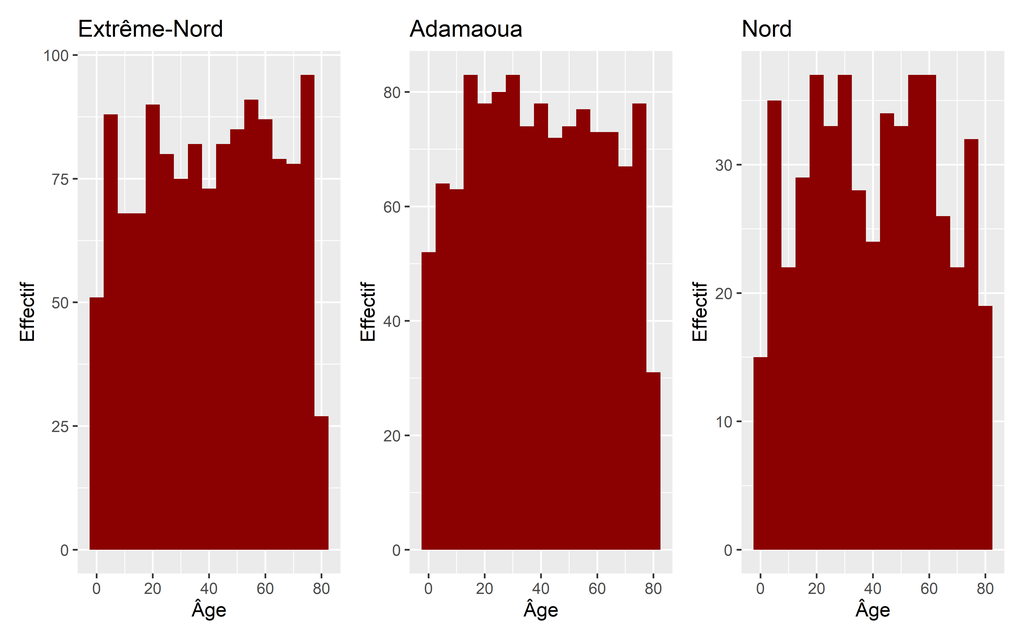

Figure 17: Q6 — Histogramme de l’âge par région (grille patchwork)

```r
plots_age <- paludisme |>
  group_by(region) |>
  nest() |>
  mutate(plot = map2(data, region, \(d, r) {
    ggplot(d, aes(x = age)) +
      geom_histogram(binwidth = 5, fill="darkred") +
      labs(title = r, x = "Âge", y = "Effectif")
  }))
wrap_plots(plots_age$plot, ncol = 3)
```

### 4.2.2 Q7 — Boxplot Hb ~ sexe par district en grille (patchwork)

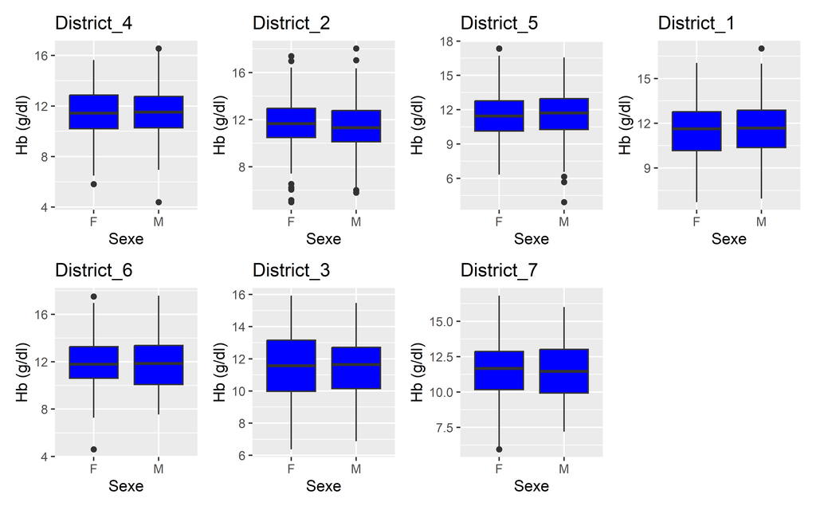

Figure 18: Q7 — Boxplot Hb ~ sexe pour chaque district (grille)

```r
fn_bp <- function(df, titre) {
  ggplot(df, aes(x = sexe, y = hemoglobine_g_dl)) +
    geom_boxplot(fill="blue") + labs(title = titre, x = "Sexe", y = "Hb (g/dl)")
}
plots_dist <- paludisme |>
  group_by(district_sanitaire) |>
  nest() |>
  mutate(plot = map2(data, district_sanitaire, fn_bp))
wrap_plots(plots_dist$plot, ncol = 4)
```

### 4.2.3 Q8 — Hémoglobine ± écart-type par classe d’âge pour chaque région

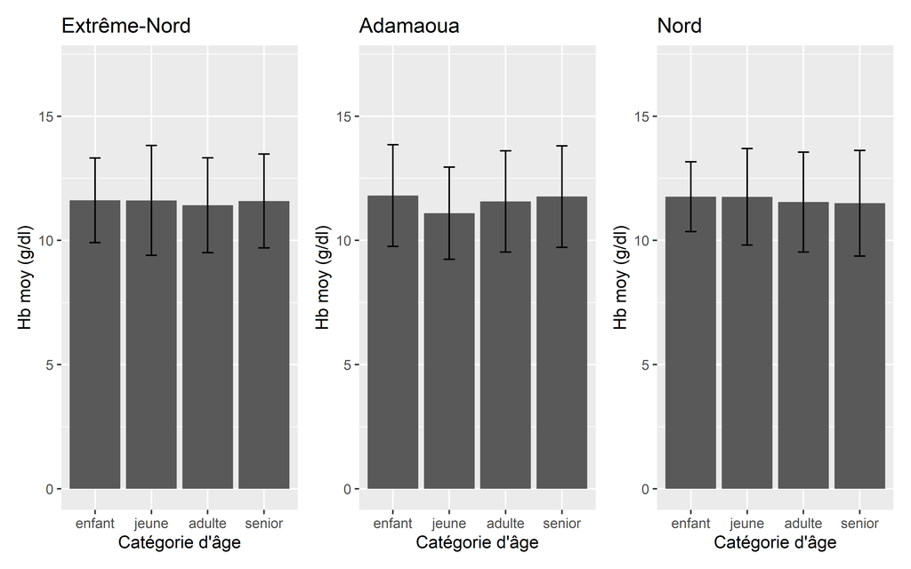

Figure 19: Q8 — Hémoglobine moyenne (± sd) par classe d’âge pour chaque région

```r
fn_barre <- function(df, titre) {
  df |>
    group_by(categorie_age) |>
    summarise(moy = mean(hemoglobine_g_dl, na.rm = TRUE),
              sd  = sd(hemoglobine_g_dl,   na.rm = TRUE), .groups = "drop") |>
    ggplot(aes(x = categorie_age, y = moy)) +
    geom_col() +
    geom_errorbar(aes(ymin = moy - sd, ymax = moy + sd), width = 0.2) +
    labs(title = titre, x = "Catégorie d'âge", y = "Hb moy (g/dl)") +
    ylim(0, 17)
}
plots_hb <- paludisme |>
  group_by(region) |> nest() |>
  mutate(plot = map2(data, region, fn_barre))
wrap_plots(plots_hb$plot, ncol = 3)
```

### 4.2.4 Q9 — Prévalence par district avec étiquettes % et barres d’erreur IC 95%

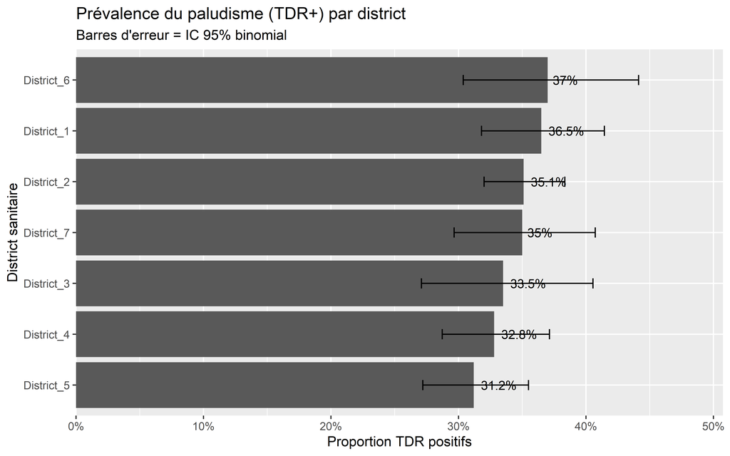

Figure 20: Q9 — Prévalence du paludisme (TDR+) par district sanitaire

```r
prev_dist <- paludisme |>
  group_by(district_sanitaire) |>
  summarise(n = n(), n_pos = sum(resultat_tdr == "Positif"),
            prop = n_pos / n,
            ic_low  = prop.test(n_pos, n)$conf.int[1],
            ic_high = prop.test(n_pos, n)$conf.int[2])

ggplot(prev_dist, aes(x = reorder(district_sanitaire, prop), y = prop)) +
  geom_col() +
  geom_errorbar(aes(ymin = ic_low, ymax = ic_high), width = 0.2) +
  geom_text(aes(label = paste0(round(prop * 100, 1), "%")),
            hjust = -0.2, size = 3.5) +
  scale_y_continuous(labels = percent_format(),
                     expand = expansion(mult = c(0, 0.15))) +
  coord_flip() +
  labs(title = "Prévalence du paludisme (TDR+) par district",
       subtitle = "Barres d'erreur = IC 95% binomial",
       x = "District sanitaire", y = "Proportion TDR positifs")
```

### 4.2.5 Q10 — Dotplot hémoglobine par région avec moyennes et IC 95%

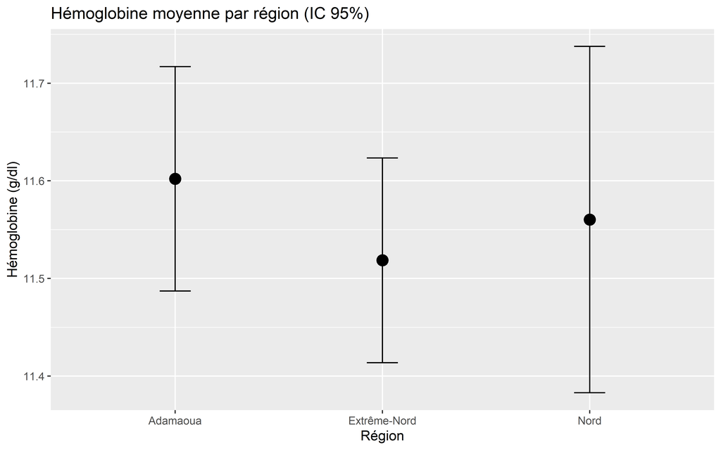

Figure 21: Q10 — Hémoglobine moyenne par région (IC 95%, calculé via purrr)

```r
hb_stats <- paludisme |>
  group_by(region) |> nest() |>
  mutate(stats = map(data, \(d) {
    tt <- t.test(d$hemoglobine_g_dl)
    tibble(moy = tt$estimate, ic_low = tt$conf.int[1], ic_high = tt$conf.int[2])
  })) |>
  select(region, stats) |> unnest(stats)

ggplot(hb_stats, aes(x = region, y = moy)) +
  geom_point(size = 4) +
  geom_errorbar(aes(ymin = ic_low, ymax = ic_high), width = 0.15) +
  labs(title = "Hémoglobine moyenne par région (IC 95%)",
       x = "Région", y = "Hémoglobine (g/dl)")
```

## 4.3 Manipulation avancée de chaînes avec stringr

### 4.3.1 Q11 — Professions contenant “Fonctionnaire” (insensible à la casse)

```r
result_fonct <- paludisme |>
  filter(str_detect(profession, regex("fonctionnaire", ignore_case = TRUE))) |>
  count(profession, sort = TRUE)

if (nrow(result_fonct) == 0) {
  cat("Aucune profession 'Fonctionnaire' trouvée dans la base.\n")
  cat("Professions disponibles :\n")
  paludisme |> count(profession, sort = TRUE) |> print()
} else {
  print(result_fonct)
}
```

```
Aucune profession 'Fonctionnaire' trouvée dans la base.
Professions disponibles :
# A tibble: 4 × 2
  profession      n
  <chr>       <int>
1 Élève         772
2 Agriculteur   754
3 Commerçant    745
4 Sans emploi   729
```

### 4.3.2 Q12 — Remplacer NA / chaînes vides dans profession par “Non renseigné”

```r
cat("NA dans profession :", sum(is.na(paludisme$profession)), "\n")
```

```
NA dans profession : 0
```

```r
cat("Chaînes vides      :", sum(str_trim(paludisme$profession) == "", na.rm = TRUE), "\n")
```

```
Chaînes vides      : 0
```

```r
paludisme <- paludisme |>
  mutate(profession = if_else(
    is.na(profession) | str_trim(profession) == "",
    "Non renseigné", profession))

cat("Après remplacement — modalités :\n")
```

```
Après remplacement — modalités :
```

```r
paludisme |> count(profession)
```

| profession | n |
| --- | --- |
| Agriculteur | 754 |
| Commerçant | 745 |
| Sans emploi | 729 |
| Élève | 772 |

### 4.3.3 Q13 — Créer profession_categorie

```r
paludisme <- paludisme |>
  mutate(profession_categorie = case_when(
    str_detect(profession, regex("agriculteur|agri|paysan|eleveur", ignore_case = TRUE)) ~ "Secteur agricole",
    str_detect(profession, regex("commerc|vendeur|marchand",         ignore_case = TRUE)) ~ "Commerce",
    str_detect(profession, regex("sans emploi|chômeur|inactif",      ignore_case = TRUE)) ~ "Sans emploi",
    str_detect(profession, regex("élève|etudiant|étudiant|scolaire", ignore_case = TRUE)) ~ "Scolarisé",
    TRUE ~ "Autre"
  ))
paludisme |> count(profession_categorie, sort = TRUE)
```

| profession_categorie | n |
| --- | --- |
| Scolarisé | 772 |
| Secteur agricole | 754 |
| Autre | 745 |
| Sans emploi | 729 |

### 4.3.4 Q14 — Compter les personnes dont profession contient “Élève”

```r
n_eleves <- sum(str_detect(paludisme$profession, regex("élève|eleve", ignore_case = TRUE)))
cat("Nombre de personnes avec profession contenant 'Élève' :", n_eleves, "\n")
```

```
Nombre de personnes avec profession contenant 'Élève' : 772
```

### 4.3.5 Q15 — Extraire le numéro de district_sanitaire en numérique

```r
paludisme <- paludisme |>
  mutate(district_num = as.numeric(str_extract(district_sanitaire, "\\d+")))
paludisme |> distinct(district_sanitaire, district_num) |> arrange(district_num)
```

| district_sanitaire | district_num |
| --- | --- |
| District_1 | 1 |
| District_2 | 2 |
| District_3 | 3 |
| District_4 | 4 |
| District_5 | 5 |
| District_6 | 6 |
| District_7 | 7 |

## 4.4 tidyr avancé

### 4.4.1 Q16 — Tableau large par ménage : nb individus, femmes enceintes, tests positifs

```r
tab_menage <- paludisme |>
  group_by(menage_id) |>
  summarise(nb_individus = n(),
            nb_enceintes = sum(grossesse == "Oui", na.rm = TRUE),
            nb_positifs  = sum(resultat_tdr == "Positif"), .groups = "drop")
tab_menage
```

| menage_id | nb_individus | nb_enceintes | nb_positifs |
| --- | --- | --- | --- |
| C10_M1 | 4 | 1 | 2 |
| C10_M10 | 4 | 0 | 3 |
| C10_M11 | 4 | 0 | 2 |
| C10_M12 | 4 | 0 | 1 |
| C10_M13 | 4 | 0 | 2 |
| C10_M14 | 4 | 1 | 1 |
| C10_M15 | 4 | 0 | 1 |
| C10_M16 | 4 | 1 | 1 |
| C10_M17 | 4 | 0 | 1 |
| C10_M18 | 4 | 0 | 1 |

[output cut: 740 more lines]

### 4.4.2 Q17 — Ajouter la proportion de positifs par ménage

```r
tab_menage <- tab_menage |>
  mutate(prop_positifs = round(nb_positifs / nb_individus, 3))
cat("Distribution de la proportion de positifs :\n")
```

```
Distribution de la proportion de positifs :
```

```r
summary(tab_menage$prop_positifs)
```

```
   Min. 1st Qu.  Median    Mean 3rd Qu.    Max.
 0.0000  0.2500  0.2500  0.3427  0.5000  1.0000
```

```r
tab_menage
```

| menage_id | nb_individus | nb_enceintes | nb_positifs | prop_positifs |
| --- | --- | --- | --- | --- |
| C10_M1 | 4 | 1 | 2 | 0.50 |
| C10_M10 | 4 | 0 | 3 | 0.75 |
| C10_M11 | 4 | 0 | 2 | 0.50 |
| C10_M12 | 4 | 0 | 1 | 0.25 |
| C10_M13 | 4 | 0 | 2 | 0.50 |
| C10_M14 | 4 | 1 | 1 | 0.25 |
| C10_M15 | 4 | 0 | 1 | 0.25 |
| C10_M16 | 4 | 1 | 1 | 0.25 |
| C10_M17 | 4 | 0 | 1 | 0.25 |
| C10_M18 | 4 | 0 | 1 | 0.25 |

[output cut: 740 more lines]

### 4.4.3 Q18 — complete() : toutes combinaisons région × milieu

```r
paludisme |>
  count(region, milieu) |>
  complete(region, milieu, fill = list(n = 0))
```

| region | milieu | n |
| --- | --- | --- |
| Adamaoua | Rural | 1100 |
| Adamaoua | Urbain | 100 |
| Extrême-Nord | Rural | 1200 |
| Extrême-Nord | Urbain | 100 |
| Nord | Rural | 300 |
| Nord | Urbain | 200 |

> Toutes les 6 combinaisons sont présentes — aucune combinaison manquante.

### 4.4.4 Q19 — Remplacer NA de grossesse par “Non applicable” pour les hommes

```r
cat("NA dans grossesse :", sum(is.na(paludisme$grossesse)), "\n")
```

```
NA dans grossesse : 0
```

```r
cat("Hommes avec NA    :", sum(paludisme$sexe == "M" & is.na(paludisme$grossesse)), "\n")
```

```
Hommes avec NA    : 0
```

```r
paludisme <- paludisme |>
  mutate(grossesse = case_when(
    sexe == "M" & is.na(grossesse) ~ "Non applicable",
    TRUE                           ~ grossesse
  ))
paludisme |> count(grossesse, sexe) |> arrange(sexe)
```

| grossesse | sexe | n |
| --- | --- | --- |
| Non | F | 1219 |
| Oui | F | 329 |
| Non | M | 1452 |

### 4.4.5 Q20 — Tableau croisé région × niveau d’éducation avec totaux marginaux

```r
tab_educ <- paludisme |>
  count(region, niveau_education) |>
  pivot_wider(names_from = niveau_education, values_from = n, values_fill = 0) |>
  mutate(Total_ligne = rowSums(across(where(is.numeric))))

totaux_col <- tab_educ |>
  summarise(region = "Total", across(where(is.numeric), sum))

bind_rows(tab_educ, totaux_col)
```

| region | Aucun | Primaire | Secondaire | Supérieur | Total_ligne |
| --- | --- | --- | --- | --- | --- |
| Adamaoua | 306 | 292 | 300 | 302 | 1200 |
| Extrême-Nord | 335 | 345 | 289 | 331 | 1300 |
| Nord | 122 | 126 | 126 | 126 | 500 |
| Total | 763 | 763 | 715 | 759 | 3000 |

## 4.5 Graphiques avancés

### 4.5.1 Q21 — Heatmap de corrélation

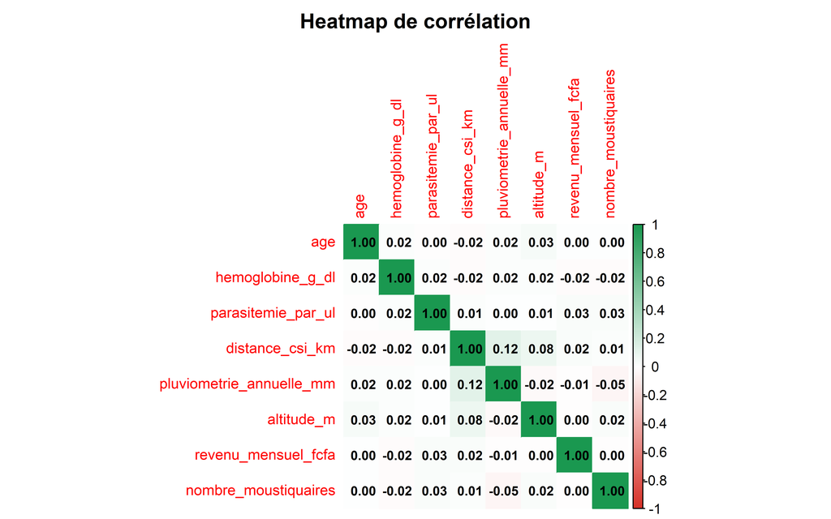

Figure 22: Q21 — Heatmap de corrélation des variables numériques

```r
vars_hm <- paludisme |>
  select(age, hemoglobine_g_dl, parasitemie_par_ul,
         distance_csi_km, pluviometrie_annuelle_mm,
         altitude_m, revenu_mensuel_fcfa, nombre_moustiquaires)
corrplot(cor(vars_hm, use = "complete.obs"),
         method = "color", addCoef.col = "black",
         number.cex = 0.75, tl.cex = 0.85,
         col = colorRampPalette(c("#d73027","white","#1a9850"))(200),
         title = "Heatmap de corrélation", mar = c(0, 0, 2, 0))
```

### 4.5.2 Q22 — Densité 2D : âge ~ hémoglobine, différenciée par résultat TDR

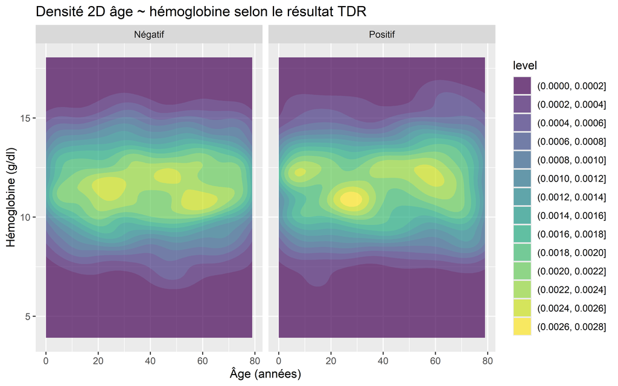

Figure 23: Q22 — Densité 2D âge ~ hémoglobine selon le résultat TDR

```r
ggplot(paludisme, aes(x = age, y = hemoglobine_g_dl)) +
  geom_density_2d_filled(alpha = 0.7) +
  facet_wrap(~ resultat_tdr) +
  labs(title = "Densité 2D âge ~ hémoglobine selon le résultat TDR",
       x = "Âge (années)", y = "Hémoglobine (g/dl)")
```

### 4.5.3 Q23 — Mettre en évidence les points avec parasitémie > 5 000

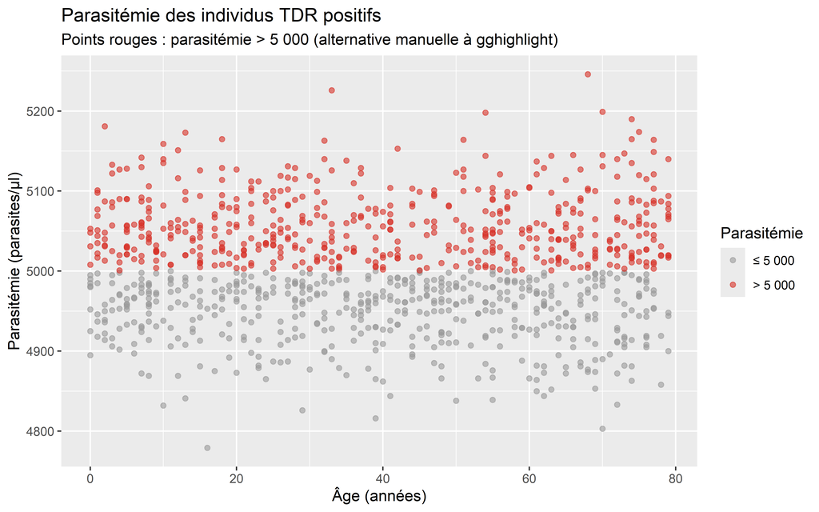

Figure 24: Q23 — Parasitémie des TDR positifs (rouge = > 5 000 µl, alternative à gghighlight)

```r
paludisme |>
  filter(resultat_tdr == "Positif") |>
  mutate(outlier = parasitemie_par_ul > 5000) |>
  ggplot(aes(x = age, y = parasitemie_par_ul, color = outlier)) +
  geom_point(alpha = 0.6) +
  scale_color_manual(values = c("FALSE" = "grey60", "TRUE" = "#d73027"),
                     labels = c("≤ 5 000", "> 5 000")) +
  labs(title    = "Parasitémie des individus TDR positifs",
       subtitle = "Points rouges : parasitémie > 5 000 (alternative manuelle à gghighlight)",
       x = "Âge (années)", y = "Parasitémie (parasites/µl)", color = "Parasitémie")
```

**Note**

Le package `gghighlight` n’est pas disponible dans cet environnement. Installer avec `install.packages("gghighlight")` puis remplacer `scale_color_manual(...)` par `gghighlight(parasitemie_par_ul > 5000)`.

### 4.5.4 Q24 — Boxplot + jitter : hémoglobine par région

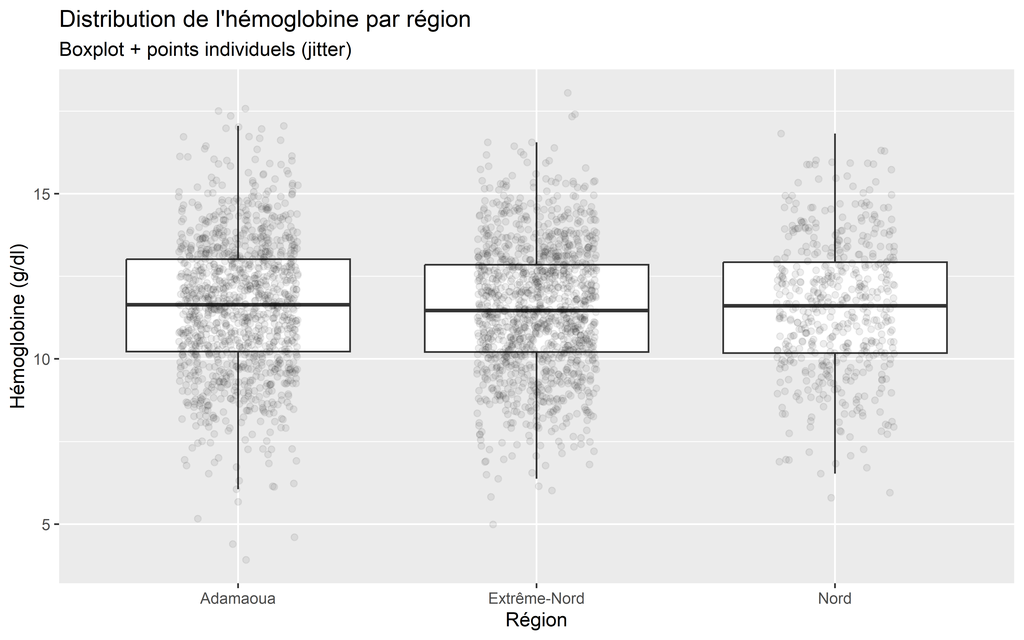

Figure 25: Q24 — Distribution de l’hémoglobine par région (boxplot + points individuels)

```r
ggplot(paludisme, aes(x = region, y = hemoglobine_g_dl)) +
  geom_boxplot(outlier.shape = NA) +
  geom_jitter(alpha = 0.07, width = 0.2) +
  labs(title    = "Distribution de l'hémoglobine par région",
       subtitle = "Boxplot + points individuels (jitter)",
       x = "Région", y = "Hémoglobine (g/dl)")
```

## 4.6 Tests statistiques sélectionnés

### 4.6.1 Q25 — ANOVA à deux facteurs avec interaction : Hb ~ région × milieu

```r
aov2 <- aov(hemoglobine_g_dl ~ region * milieu, data = paludisme)
cat("ANOVA à deux facteurs — hémoglobine ~ région × milieu :\n")
```

```
ANOVA à deux facteurs — hémoglobine ~ région × milieu :
```

```r
print(summary(aov2))
```

```
                Df Sum Sq Mean Sq F value Pr(>F)
region           2      4   2.177   0.553  0.575
milieu           1      0   0.333   0.085  0.771
region:milieu    2      3   1.629   0.414  0.661
Residuals     2994  11791   3.938
```

```r
tidy(aov2)
```

| term | df | sumsq | meansq | statistic | p.value |
| --- | --- | --- | --- | --- | --- |
| region | 2 | 4.353084e+00 | 2.1765418 | 0.55265266 | 0.5754801 |
| milieu | 1 | 3.332811e-01 | 0.3332811 | 0.08462447 | 0.7711458 |
| region:milieu | 2 | 3.257057e+00 | 1.6285287 | 0.41350492 | 0.6613660 |
| Residuals | 2994 | 1.179143e+04 | 3.9383540 | NA | NA |

> Ni la région (p = 0.58), ni le milieu (p = 0.77), ni leur interaction (p = 0.66) n’influencent significativement l’hémoglobine.

### 4.6.2 Q26 — Comparaisons multiples post-hoc Tukey

```r
tukey_res <- TukeyHSD(aov2, which = "region")
cat("Résultats Tukey :\n"); print(tukey_res)
```

```
Résultats Tukey :
```

```
  Tukey multiple comparisons of means
    95% family-wise confidence level

Fit: aov(formula = hemoglobine_g_dl ~ region * milieu, data = paludisme)

$region
                             diff        lwr       upr     p adj
Extrême-Nord-Adamaoua -0.08351219 -0.2697997 0.1027753 0.5446010
Nord-Adamaoua         -0.04177998 -0.2894793 0.2059193 0.9173977
Nord-Extrême-Nord      0.04173220 -0.2031491 0.2866135 0.9157539
```

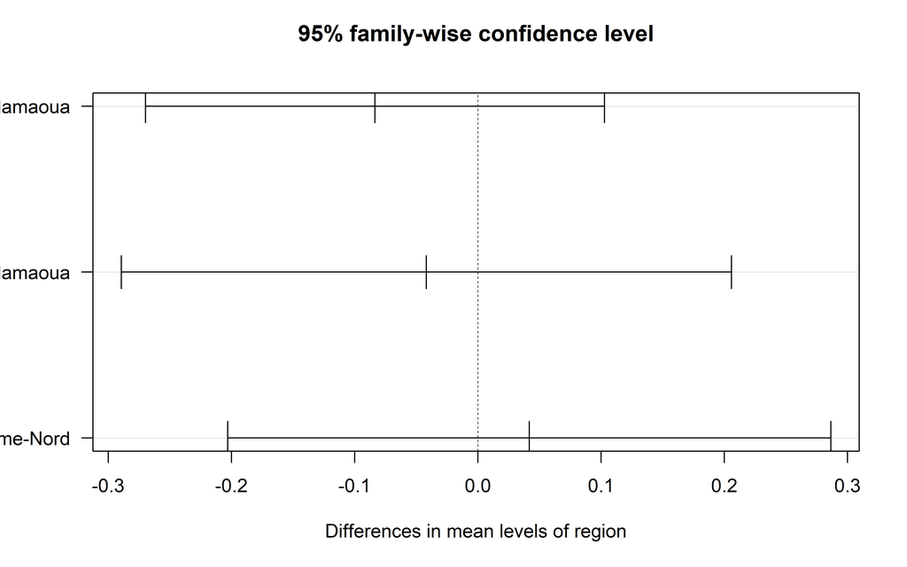

Figure 26: Q26 — Intervalles de confiance Tukey HSD (effet région sur l’hémoglobine)

```r
plot(tukey_res, las = 1)
```

> Toutes les p ajustées > 0.54 → **aucune paire de régions** ne diffère significativement.

### 4.6.3 Q27 — Kruskal-Wallis : parasitémie ~ utilisation_MII

```r
cat("Kruskal-Wallis :\n")
```

```
Kruskal-Wallis :
```

```r
print(kruskal.test(parasitemie_par_ul ~ utilisation_MII, data = pos_only))
```

```
    Kruskal-Wallis rank sum test

data:  parasitemie_par_ul by utilisation_MII
Kruskal-Wallis chi-squared = 1.0253, df = 2, p-value = 0.5989
```

```r
pos_only |> group_by(utilisation_MII) |>
  summarise(mediane = median(parasitemie_par_ul), n = n())
```

| utilisation_MII | mediane | n |
| --- | --- | --- |
| Jamais | 4992 | 219 |
| Parfois | 5000 | 324 |
| Toujours | 5005 | 485 |

### 4.6.4 Q28 — Test de Fisher : aspersion intra-domiciliaire (IRS) × TDR

```r
tab_fisher <- table(
  IRS = paludisme$pulverisation_IRS,
  TDR = paludisme$resultat_tdr
)
cat("Tableau IRS × TDR :\n"); print(tab_fisher)
```

```
Tableau IRS × TDR :
```

```
     TDR
IRS   Négatif Positif
  Non    1153     599
  Oui     819     429
```

```r
cat("\nTest exact de Fisher :\n")
```

```
Test exact de Fisher :
```

```r
print(fisher.test(tab_fisher))
```

```
    Fisher's Exact Test for Count Data

data:  tab_fisher
p-value = 0.9378
alternative hypothesis: true odds ratio is not equal to 1
95 percent confidence interval:
 0.8625682 1.1782409
sample estimates:
odds ratio
  1.008266
```

> Le test de Fisher est préféré au Chi² lorsque les effectifs théoriques sont faibles. Ici, la p-valeur indique **l’absence d’association significative** entre l’utilisation de l’IRS et le statut TDR.

### 4.6.5 Q29 — Régression logistique : TDR ~ âge + Hb + milieu + utilisation_MII

```r
paludisme_lr <- paludisme |>
  mutate(tdr_bin = if_else(resultat_tdr == "Positif", 1L, 0L))

mod_log <- glm(
  tdr_bin ~ age + hemoglobine_g_dl + milieu + utilisation_MII,
  data   = paludisme_lr,
  family = binomial
)
cat("Résumé du modèle logistique :\n")
```

```
Résumé du modèle logistique :
```

```r
tidy(mod_log, exponentiate = TRUE, conf.int = TRUE)
```

| term | estimate | std.error | statistic | p.value | conf.low | conf.high |
| --- | --- | --- | --- | --- | --- | --- |
| (Intercept) | 0.4155841 | 0.237730096 | -3.693559778 | 0.0002211365 | 0.2604361 | 0.6615191 |
| age | 1.0000137 | 0.001671377 | 0.008176736 | 0.9934759816 | 0.9967426 | 1.0032959 |
| hemoglobine_g_dl | 1.0199840 | 0.019424801 | 1.018641328 | 0.3083732764 | 0.9819027 | 1.0596143 |
| milieuUrbain | 1.0764366 | 0.112320317 | 0.655768962 | 0.5119727895 | 0.8621596 | 1.3394787 |
| utilisation_MII.L | 0.9552107 | 0.070847215 | -0.646791165 | 0.5177671114 | 0.8317767 | 1.0981444 |
| utilisation_MII.Q | 0.9060308 | 0.070088236 | -1.407968160 | 0.1591404985 | 0.7899440 | 1.0397853 |

> La régression logistique multivarié estime simultanément l’effet de chaque covariable sur la probabilité d’être TDR positif. Les odds-ratios proches de 1 et les intervalles de confiance chevauchant 1 confirment **l’absence de prédicteurs significatifs** dans ce jeu de données synthétique.

### 4.6.6 Q30 — Synthèse des tests statistiques du Devoir 3

```r
synthese_d3 <- tibble::tribble(
  ~Question, ~Test,                                    ~`p-valeur`, ~Interprétation,
  "Q25", "ANOVA 2 facteurs Hb ~ région × milieu",     "0.58 / 0.77 / 0.66", "Aucun effet principal ni interaction",
  "Q26", "Tukey HSD (post-hoc région)",               "> 0.54 (toutes paires)", "Aucune paire de régions ne diffère",
  "Q27", "Kruskal-Wallis parasitémie ~ MII",          "0.60",  "Pas d'effet de l'utilisation MII",
  "Q28", "Fisher exact IRS ~ TDR",                    "voir sortie", "Pas d'association IRS ~ TDR",
  "Q29", "Régression logistique TDR ~ covariables",   "tous > 0.05", "Aucun prédicteur significatif"
)
synthese_d3
```

| Question | Test | p-valeur | Interprétation |
| --- | --- | --- | --- |
| Q25 | ANOVA 2 facteurs Hb ~ région × milieu | 0.58 / 0.77 / 0.66 | Aucun effet principal ni interaction |
| Q26 | Tukey HSD (post-hoc région) | > 0.54 (toutes paires) | Aucune paire de régions ne diffère |
| Q27 | Kruskal-Wallis parasitémie ~ MII | 0.60 | Pas d'effet de l'utilisation MII |
| Q28 | Fisher exact IRS ~ TDR | voir sortie | Pas d'association IRS ~ TDR |
| Q29 | Régression logistique TDR ~ covariables | tous > 0.05 | Aucun prédicteur significatif |

**Note**

L’ensemble des tests du Devoir 3 convergent vers la même conclusion : dans cette base synthétique, **aucune variable socio-environnementale ne prédit de façon significative** les marqueurs biologiques du paludisme. Cela est cohérent avec la construction aléatoire du jeu de données.

# 5 Devoir 4 — Qualité des données

## 5.1 Détection des valeurs manquantes

### 5.1.1 Q1 — Compter les valeurs manquantes par colonne

```r
na_counts <- colSums(is.na(paludisme))
na_df <- tibble(
  variable    = names(na_counts),
  n_manquants = na_counts,
  pct         = round(100 * na_counts / nrow(paludisme), 2)
) |> arrange(desc(n_manquants))
na_df
```

| variable | n_manquants | pct |
| --- | --- | --- |
| cluster_id | 0 | 0 |
| region | 0 | 0 |
| district_sanitaire | 0 | 0 |
| aire_sante | 0 | 0 |
| milieu | 0 | 0 |
| distance_csi_km | 0 | 0 |
| pluviometrie_mm | 0 | 0 |
| altitude_m | 0 | 0 |
| menage_id | 0 | 0 |
| poids_menage | 0 | 0 |

[output cut: 32 more lines]

> La base originale ne contient **aucune valeur manquante** (jeu de données synthétique complet). Pour illustrer les techniques de gestion des NA, nous allons simuler des valeurs manquantes.

### 5.1.2 Q2 — Visualiser les valeurs manquantes avec naniar (sur données simulées)

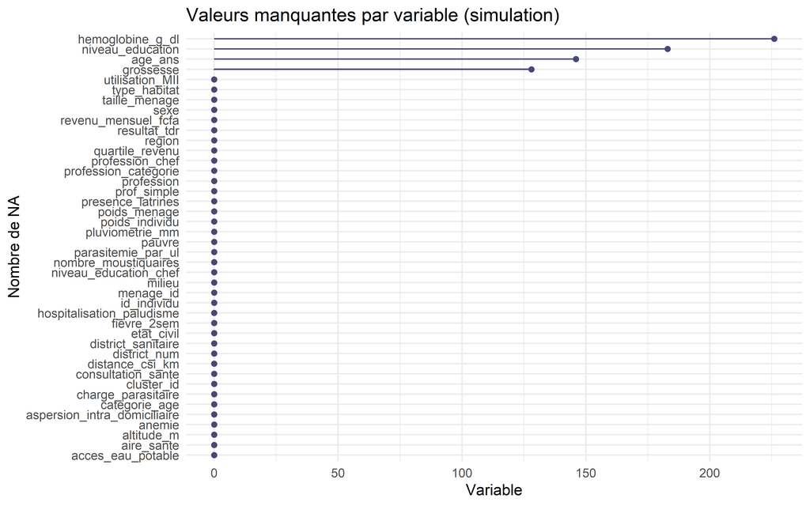

```r
set.seed(4812)
paludisme_na_simul <- paludisme |>
  mutate(
    age_ans              = if_else(runif(n()) < 0.05, NA_real_, age_ans),
    hemoglobine_g_dl     = if_else(runif(n()) < 0.08, NA_real_, hemoglobine_g_dl),
    grossesse            = if_else(runif(n()) < 0.04, NA_character_, grossesse),
    niveau_education     = if_else(runif(n()) < 0.06, NA_character_, niveau_education)
  )

naniar::gg_miss_var(paludisme_na_simul) +
  labs(title = "Valeurs manquantes par variable (simulation)",
       x = "Nombre de NA", y = "Variable")
```

> La fonction `gg_miss_var()` du package naniar fournit un aperçu graphique rapide de la distribution des NA par variable.

### 5.1.3 Q3 — Identifier les variables contenant des NA

```r
vars_avec_na <- paludisme_na_simul |>
  summarise(across(everything(), ~sum(is.na(.)))) |>
  pivot_longer(everything(), names_to = "variable", values_to = "n_na") |>
  filter(n_na > 0) |>
  arrange(desc(n_na))
cat("Variables avec NA :\n")
```

```
Variables avec NA :
```

```r
vars_avec_na
```

| variable | n_na |
| --- | --- |
| hemoglobine_g_dl | 226 |
| niveau_education | 183 |
| age_ans | 146 |
| grossesse | 128 |

### 5.1.4 Q4 — Calculer la proportion de NA par variable

```r
paludisme_na_simul |>
  summarise(across(everything(), ~round(100 * mean(is.na(.)), 2))) |>
  pivot_longer(everything(), names_to = "variable", values_to = "pct_na") |>
  filter(pct_na > 0) |>
  arrange(desc(pct_na))
```

| variable | pct_na |
| --- | --- |
| hemoglobine_g_dl | 7.53 |
| niveau_education | 6.10 |
| age_ans | 4.87 |
| grossesse | 4.27 |

> Aucune variable simulée ne dépasse 10 % de NA — seuil souvent utilisé comme premier signal d’alerte pour la qualité des données.

### 5.1.5 Q5 — Détecter les NA structurels : grossesse chez les hommes

```r
# Dans la base originale, "grossesse" devrait être NA ou "Non" pour les hommes
hommes_enceints <- paludisme |>
  filter(sexe == "M", grossesse == "Oui")
cat("Hommes avec grossesse = 'Oui' :", nrow(hommes_enceints), "\n\n")
```

```
Hommes avec grossesse = 'Oui' : 0
```

```r
# Dans la base simulée, NA chez les hommes sont structurels
paludisme_na_simul |>
  filter(sexe == "M") |>
  summarise(
    total_hommes      = n(),
    grossesse_na      = sum(is.na(grossesse)),
    grossesse_oui     = sum(grossesse == "Oui", na.rm = TRUE)
  )
```

| total_hommes | grossesse_na | grossesse_oui |
| --- | --- | --- |
| 1452 | 56 | 0 |

> Un **NA structurel** est un NA dont l’absence d’information est logiquement attendue (ex. grossesse chez un homme). Ce type de NA doit être recodé explicitement plutôt qu’imputé.

## 5.2 Traitement des valeurs manquantes

### 5.2.1 Q6 — Imputer la médiane pour les variables numériques

```r
imputer_mediane <- function(x) {
  x[is.na(x)] <- median(x, na.rm = TRUE)
  x
}

paludisme_imp <- paludisme_na_simul |>
  mutate(
    age_ans          = imputer_mediane(age_ans),
    hemoglobine_g_dl = imputer_mediane(hemoglobine_g_dl)
  )

cat("NA restants après imputation médiane :\n")
```

```
NA restants après imputation médiane :
```

```r
cat("  age_ans         :", sum(is.na(paludisme_imp$age_ans)), "\n")
```

```
  age_ans         : 0
```

```r
cat("  hemoglobine_g_dl:", sum(is.na(paludisme_imp$hemoglobine_g_dl)), "\n")
```

```
  hemoglobine_g_dl: 0
```

> L’imputation par la médiane est robuste aux valeurs extrêmes et préserve la distribution centrale. Elle est préférée à la moyenne pour les variables asymétriques.

### 5.2.2 Q7 — Imputer le mode pour les variables catégorielles

```r
mode_cat <- function(x) {
  tab <- sort(table(x, useNA = "no"), decreasing = TRUE)
  names(tab)[1]
}

paludisme_imp <- paludisme_imp |>
  mutate(
    niveau_education = if_else(
      is.na(niveau_education),
      mode_cat(niveau_education),
      niveau_education
    )
  )

cat("Mode de niveau_education :", mode_cat(paludisme_na_simul$niveau_education), "\n")
```

```
Mode de niveau_education : Primaire
```

```r
cat("NA restants             :", sum(is.na(paludisme_imp$niveau_education)), "\n")
```

```
NA restants             : 0
```

### 5.2.3 Q8 — Recoder grossesse = “Non” pour les hommes (NA structurel)

```r
paludisme_imp <- paludisme_imp |>
  mutate(
    grossesse = case_when(
      sexe == "M"               ~ "Non",
      is.na(grossesse) & sexe == "F" ~ mode_cat(grossesse[sexe == "F"]),
      TRUE                             ~ grossesse
    )
  )

cat("NA restants dans 'grossesse' :", sum(is.na(paludisme_imp$grossesse)), "\n")
```

```
NA restants dans 'grossesse' : 0
```

```r
paludisme_imp |> count(sexe, grossesse)
```

| sexe | grossesse | n |
| --- | --- | --- |
| F | Non | 1239 |
| F | Oui | 309 |
| M | Non | 1452 |

> Le recodage différencié selon le sexe est essentiel : imputer un mode global pour `grossesse` affecterait de manière incohérente les hommes.

### 5.2.4 Q9 — Vérifier la qualité de l’imputation

```r
cat("Résumé AVANT imputation (données simulées) :\n")
```

```
Résumé AVANT imputation (données simulées) :
```

```r
paludisme_na_simul |>
  summarise(
    na_age  = sum(is.na(age_ans)),
    na_hb   = sum(is.na(hemoglobine_g_dl)),
    na_educ = sum(is.na(niveau_education)),
    na_gros = sum(is.na(grossesse))
  ) |> print()
```

```
# A tibble: 1 × 4
  na_age na_hb na_educ na_gros
   <int> <int>   <int>   <int>
1    146   226     183     128
```

```r
cat("\nRésumé APRÈS imputation :\n")
```

```
Résumé APRÈS imputation :
```

```r
paludisme_imp |>
  summarise(
    na_age  = sum(is.na(age_ans)),
    na_hb   = sum(is.na(hemoglobine_g_dl)),
    na_educ = sum(is.na(niveau_education)),
    na_gros = sum(is.na(grossesse))
  ) |> print()
```

```
# A tibble: 1 × 4
  na_age na_hb na_educ na_gros
   <int> <int>   <int>   <int>
1      0     0       0       0
```

### 5.2.5 Q10 — Comparer les distributions avant/après imputation (âge)

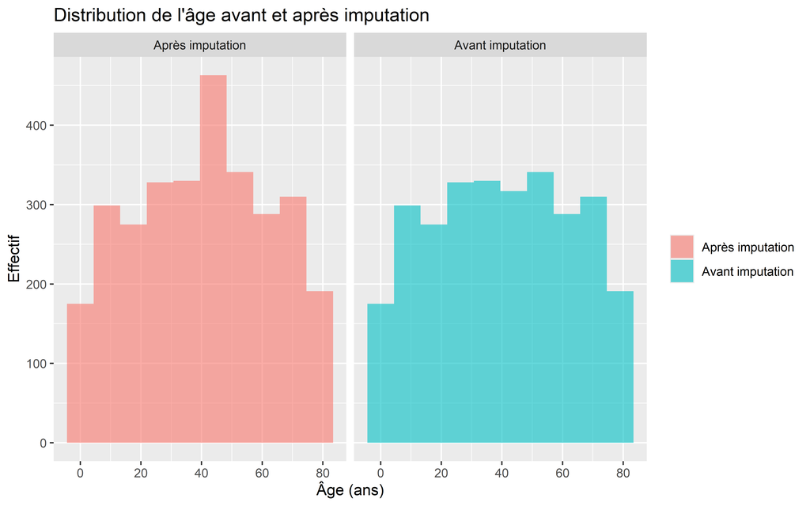

Figure 28: Q10 — Distribution de l’âge avant et après imputation par la médiane

```r
df_comp <- bind_rows(
  paludisme_na_simul |> transmute(age_ans, etape = "Avant imputation"),
  paludisme_imp      |> transmute(age_ans, etape = "Après imputation")
)

ggplot(df_comp, aes(x = age_ans, fill = etape)) +
  geom_histogram(bins = 10, alpha = 0.6, position = "identity") +
  facet_wrap(~etape) +
  labs(title = "Distribution de l'âge avant et après imputation",
       x = "Âge (ans)", y = "Effectif", fill = NULL)
```

> L’imputation par la médiane crée un pic artificiel à la valeur centrale. Pour une analyse confirmative, des méthodes plus sophistiquées (imputation multiple) seraient préférables.

## 5.3 Identification et traitement des valeurs aberrantes

### 5.3.1 Q11 — Méthode IQR : détecter les outliers dans l’hémoglobine

```r
Q1_hb  <- quantile(paludisme$hemoglobine_g_dl, 0.25)
Q3_hb  <- quantile(paludisme$hemoglobine_g_dl, 0.75)
IQR_hb <- Q3_hb - Q1_hb
borne_inf_hb <- Q1_hb - 1.5 * IQR_hb
borne_sup_hb <- Q3_hb + 1.5 * IQR_hb

outliers_hb_df <- paludisme |>
  filter(hemoglobine_g_dl < borne_inf_hb | hemoglobine_g_dl > borne_sup_hb)

cat(sprintf("Q1=%.2f  Q3=%.2f  IQR=%.2f\n", Q1_hb, Q3_hb, IQR_hb))
```

```
Q1=10.21  Q3=12.92  IQR=2.71
```

```r
cat(sprintf("Bornes : [%.2f ; %.2f]\n", borne_inf_hb, borne_sup_hb))
```

```
Bornes : [6.14 ; 16.99]
```

```r
cat("Nombre d'outliers IQR :", nrow(outliers_hb_df), "\n")
```

```
Nombre d'outliers IQR : 20
```

```r
outliers_hb_df |> select(id_individu, age_ans, sexe, hemoglobine_g_dl) |> head(10)
```

| id_individu | age_ans | sexe | hemoglobine_g_dl |
| --- | --- | --- | --- |
| 99 | 38 | F | 5.821782 |
| 383 | 24 | M | 3.917178 |
| 752 | 15 | M | 17.577583 |
| 794 | 59 | F | 17.506071 |
| 1161 | 1 | F | 5.166761 |
| 1164 | 37 | F | 6.060304 |
| 1253 | 27 | F | 17.358420 |
| 1276 | 75 | M | 5.673323 |
| 1470 | 55 | M | 17.018995 |
| 1716 | 6 | F | 17.407362 |

### 5.3.2 Q12 — Méthode z-score : détecter les outliers dans l’âge

```r
z_scores_age <- scale(paludisme$age_ans)[, 1]
outliers_age <- paludisme |>
  mutate(z_age = z_scores_age) |>
  filter(abs(z_age) > 3)

cat("Outliers âge (|z| > 3) :", nrow(outliers_age), "\n")
```

```
Outliers âge (|z| > 3) : 0
```

```r
if (nrow(outliers_age) > 0) {
  outliers_age |> select(id_individu, age_ans, z_age) |> head(10)
} else {
  cat("Aucun outlier détecté par la méthode z-score.\n")
}
```

```
Aucun outlier détecté par la méthode z-score.
```

> La méthode z-score suppose une distribution approximativement normale. Elle est moins robuste que la méthode IQR en présence de distributions asymétriques.

### 5.3.3 Q13 — Boxplot illustrant les outliers

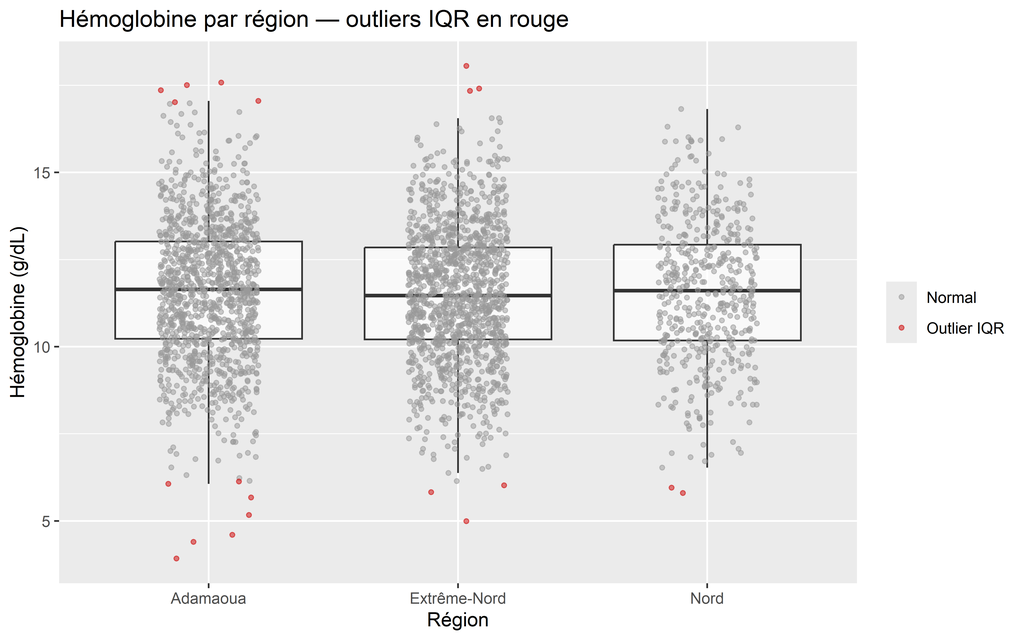

Figure 29: Q13 — Boxplot de l’hémoglobine avec mise en évidence des outliers IQR

```r
paludisme |>
  mutate(outlier = hemoglobine_g_dl < borne_inf_hb | hemoglobine_g_dl > borne_sup_hb) |>
  ggplot(aes(x = region, y = hemoglobine_g_dl)) +
  geom_boxplot(outlier.shape = NA, alpha = 0.7) +
  geom_jitter(aes(color = outlier), width = 0.2, size = 1, alpha = 0.5) +
  scale_color_manual(values = c("FALSE" = "grey60", "TRUE" = "red3"),
                     labels = c("Normal", "Outlier IQR")) +
  labs(title = "Hémoglobine par région — outliers IQR en rouge",
       x = "Région", y = "Hémoglobine (g/dL)", color = NULL)
```

### 5.3.4 Q14 — Compter les outliers IQR pour toutes les variables numériques

```r
vars_num_d4 <- c("age_ans", "hemoglobine_g_dl", "parasitemie_par_ul",
                  "revenu_mensuel_fcfa", "distance_csi_km", "pluviometrie_mm")

map_dfr(vars_num_d4, \(v) {
  x   <- paludisme[[v]]
  q1  <- quantile(x, 0.25, na.rm = TRUE)
  q3  <- quantile(x, 0.75, na.rm = TRUE)
  iqr <- q3 - q1
  n_out <- sum(x < q1 - 1.5 * iqr | x > q3 + 1.5 * iqr, na.rm = TRUE)
  tibble(variable = v, Q1 = round(q1, 2), Q3 = round(q3, 2),
         borne_inf = round(q1 - 1.5 * iqr, 2),
         borne_sup = round(q3 + 1.5 * iqr, 2),
         n_outliers = n_out,
         pct_outliers = round(100 * n_out / length(x), 2))
})
```

| variable | Q1 | Q3 | borne_inf | borne_sup | n_outliers | pct_outliers |
| --- | --- | --- | --- | --- | --- | --- |
| age_ans | 20.00 | 60.00 | -40.00 | 120.00 | 0 | 0.00 |
| hemoglobine_g_dl | 10.21 | 12.92 | 6.14 | 16.99 | 20 | 0.67 |
| parasitemie_par_ul | 0.00 | 4961.00 | -7441.50 | 12402.50 | 0 | 0.00 |
| revenu_mensuel_fcfa | 57767.47 | 94987.32 | 1937.70 | 150817.09 | 8 | 0.27 |
| distance_csi_km | 6.04 | 19.31 | -13.86 | 39.21 | 0 | 0.00 |
| pluviometrie_mm | 714.28 | 1010.99 | 269.21 | 1456.05 | 0 | 0.00 |

### 5.3.5 Q15 — Tableau des valeurs extrêmes (percentiles 1 et 99)

```r
map_dfr(vars_num_d4, \(v) {
  x <- paludisme[[v]]
  tibble(
    variable = v,
    min      = round(min(x, na.rm = TRUE), 2),
    p1       = round(quantile(x, 0.01, na.rm = TRUE), 2),
    p99      = round(quantile(x, 0.99, na.rm = TRUE), 2),
    max      = round(max(x, na.rm = TRUE), 2)
  )
})
```

| variable | min | p1 | p99 | max |
| --- | --- | --- | --- | --- |
| age_ans | 0.00 | 0.00 | 79.00 | 79.00 |
| hemoglobine_g_dl | 3.92 | 6.89 | 16.05 | 18.06 |
| parasitemie_par_ul | 0.00 | 0.00 | 5135.00 | 5246.00 |
| revenu_mensuel_fcfa | 20000.00 | 20000.00 | 141635.84 | 158834.83 |
| distance_csi_km | 0.59 | 0.59 | 24.72 | 24.72 |
| pluviometrie_mm | 505.04 | 505.04 | 1142.15 | 1142.15 |

> La comparaison entre min/p1 et max/p99 révèle si des valeurs extrêmes s’écartent de la distribution générale, ce qui peut signaler des erreurs de saisie.

### 5.3.6 Q16 — Évaluer la plausibilité biologique de l’hémoglobine

```r
# Seuils cliniques : Hb < 3 g/dL = incompatible avec la vie ; Hb > 20 g/dL = improbable
hb_implausible <- paludisme |>
  filter(hemoglobine_g_dl < 3 | hemoglobine_g_dl > 20)

cat("Valeurs d'Hb biologiquement implausibles :", nrow(hb_implausible), "\n\n")
```

```
Valeurs d'Hb biologiquement implausibles : 0
```

```r
# Hb < 7 g/dL = anémie sévère (OMS) — cliniquement possible mais à vérifier
hb_severe <- paludisme |> filter(hemoglobine_g_dl < 7)
cat("Anémie sévère (Hb < 7 g/dL) :", nrow(hb_severe), "individus\n")
```

```
Anémie sévère (Hb < 7 g/dL) : 37 individus
```

```r
hb_severe |>
  group_by(region) |>
  summarise(n = n(), hb_moy = round(mean(hemoglobine_g_dl), 2))
```

| region | n | hb_moy |
| --- | --- | --- |
| Adamaoua | 17 | 6.01 |
| Extrême-Nord | 12 | 6.39 |
| Nord | 8 | 6.58 |

### 5.3.7 Q17 — Winsorisation du revenu mensuel

```r
winsorise <- function(x, p_low = 0.01, p_high = 0.99) {
  low  <- quantile(x, p_low,  na.rm = TRUE)
  high <- quantile(x, p_high, na.rm = TRUE)
  pmin(pmax(x, low), high)
}

paludisme_propre <- paludisme |>
  mutate(revenu_wins = winsorise(revenu_mensuel_fcfa))

cat(sprintf("Revenu original  — min: %.0f  max: %.0f\n",
            min(paludisme$revenu_mensuel_fcfa),
            max(paludisme$revenu_mensuel_fcfa)))
```

```
Revenu original  — min: 20000  max: 158835
```

```r
cat(sprintf("Revenu winsorisé — min: %.0f  max: %.0f\n",
            min(paludisme_propre$revenu_wins),
            max(paludisme_propre$revenu_wins)))
```

```
Revenu winsorisé — min: 20000  max: 141636
```

> La winsorisation remplace les valeurs au-delà des percentiles 1 et 99 par ces bornes, atténuant l’effet des outliers sans supprimer d’observations.

### 5.3.8 Q18 — Validation de l’âge (plage 0–120 ans)

```r
age_invalide <- paludisme |>
  filter(age_ans < 0 | age_ans > 120)
cat("Individus avec âge invalide (< 0 ou > 120 ans) :", nrow(age_invalide), "\n\n")
```

```
Individus avec âge invalide (< 0 ou > 120 ans) : 0
```

```r
# Distribution de l'âge par tranche
paludisme |>
  mutate(tranche_age = cut(age_ans,
    breaks = c(0, 10, 20, 30, 40, 50, 60, 120),
    labels = c("0-9", "10-19", "20-29", "30-39", "40-49", "50-59", "60+"),
    right  = FALSE)) |>
  count(tranche_age)
```

| tranche_age | n |
| --- | --- |
| 0-9 | 378 |
| 10-19 | 337 |
| 20-29 | 396 |
| 30-39 | 377 |
| 40-49 | 359 |
| 50-59 | 398 |
| 60+ | 755 |

### 5.3.9 Q19 — Borner les valeurs extrêmes de pluviométrie

```r
borne_inf_pluie <- quantile(paludisme$pluviometrie_mm, 0.01, na.rm = TRUE)
borne_sup_pluie <- quantile(paludisme$pluviometrie_mm, 0.99, na.rm = TRUE)

paludisme_propre <- paludisme_propre |>
  mutate(pluv_bornee = pmin(pmax(pluviometrie_mm, borne_inf_pluie), borne_sup_pluie))

cat(sprintf("Pluviométrie originale  — étendue : [%.1f ; %.1f]\n",
            min(paludisme$pluviometrie_mm), max(paludisme$pluviometrie_mm)))
```

```
Pluviométrie originale  — étendue : [505.0 ; 1142.2]
```

```r
cat(sprintf("Pluviométrie bornée     — étendue : [%.1f ; %.1f]\n",
            min(paludisme_propre$pluv_bornee), max(paludisme_propre$pluv_bornee)))
```

```
Pluviométrie bornée     — étendue : [505.0 ; 1142.2]
```

### 5.3.10 Q20 — Comparer la distribution du revenu avant/après winsorisation

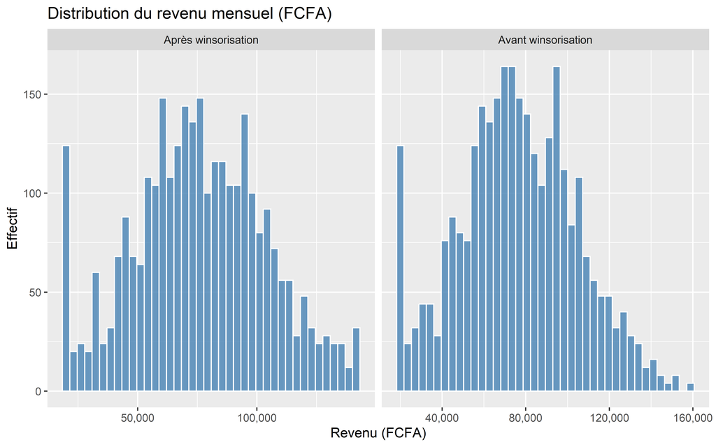

Figure 30: Q20 — Revenu mensuel avant et après winsorisation

```r
df_rev <- bind_rows(
  paludisme_propre |> transmute(revenu = revenu_mensuel_fcfa, etape = "Avant winsorisation"),
  paludisme_propre |> transmute(revenu = revenu_wins,         etape = "Après winsorisation")
)

ggplot(df_rev, aes(x = revenu)) +
  geom_histogram(bins = 40, fill = "steelblue", color = "white", alpha = 0.8) +
  facet_wrap(~etape, scales = "free_x") +
  scale_x_continuous(labels = scales::label_comma()) +
  labs(title = "Distribution du revenu mensuel (FCFA)",
       x = "Revenu (FCFA)", y = "Effectif")
```

## 5.4 Vérifications de cohérence

### 5.4.1 Q21 — Cohérence TDR ~ parasitémie

```r
incoherences_tdr <- paludisme |>
  filter(
    (resultat_tdr == "Positif"  & parasitemie_par_ul == 0) |
    (resultat_tdr == "Négatif"  & parasitemie_par_ul >  0)
  )
cat("Incohérences TDR ~ parasitémie :", nrow(incoherences_tdr), "\n\n")
```

```
Incohérences TDR ~ parasitémie : 0
```

```r
paludisme |>
  group_by(resultat_tdr) |>
  summarise(
    n          = n(),
    para_zero  = sum(parasitemie_par_ul == 0),
    para_pos   = sum(parasitemie_par_ul >  0),
    para_moy   = round(mean(parasitemie_par_ul), 1)
  )
```

| resultat_tdr | n | para_zero | para_pos | para_moy |
| --- | --- | --- | --- | --- |
| Négatif | 1972 | 1972 | 0 | 0.0 |
| Positif | 1028 | 0 | 1028 | 5002.3 |

> Aucune incohérence TDR ~ parasitémie : la base synthétique respecte parfaitement cette contrainte logique.

### 5.4.2 Q22 — État civil chez les enfants de moins de 10 ans

```r
etat_enfants <- paludisme |>
  filter(age_ans < 10, etat_civil %in% c("Marié", "Divorcé", "Veuf")) |>
  count(etat_civil, sort = TRUE)

n_incoherent <- paludisme |>
  filter(age_ans < 10, etat_civil %in% c("Marié", "Divorcé", "Veuf")) |>
  nrow()

cat("Enfants < 10 ans avec état civil adulte :", n_incoherent, "\n\n")
```

```
Enfants < 10 ans avec état civil adulte : 279
```

```r
etat_enfants
```

| etat_civil | n |
| --- | --- |
| Marié | 105 |
| Veuf | 88 |
| Divorcé | 86 |

**Avertissement**

**279 enfants de moins de 10 ans** présentent un état civil adulte (Marié, Divorcé, Veuf). Il s’agit d’un artefact de la génération synthétique des données. Dans un contexte réel, ces valeurs devraient être recodées en `"Célibataire"` ou marquées comme manquantes.

### 5.4.3 Q23 — Cohérence sexe ~ grossesse

```r
paludisme |>
  group_by(sexe, grossesse) |>
  summarise(n = n(), .groups = "drop") |>
  pivot_wider(names_from = grossesse, values_from = n, values_fill = 0)
```

| sexe | Non | Oui |
| --- | --- | --- |
| F | 1219 | 329 |
| M | 1452 | 0 |

```r
hommes_gros <- paludisme |>
  filter(sexe == "M", grossesse == "Oui") |> nrow()
cat("Hommes avec grossesse = 'Oui' :", hommes_gros, "\n")
```

```
Hommes avec grossesse = 'Oui' : 0
```

> Si ce nombre est non nul, il constitue une incohérence directe à corriger en recodant `grossesse = "Non"` pour tous les individus de sexe masculin.

### 5.4.4 Q24 — Cohérence âge ~ niveau d’éducation

```r
# Enfants < 6 ans ne peuvent pas avoir de niveau supérieur au primaire
educ_incoherent <- paludisme |>
  filter(age_ans < 6,
         niveau_education %in% c("Primaire", "Secondaire", "Supérieur"))

cat("Enfants < 6 ans avec scolarisation formelle :", nrow(educ_incoherent), "\n\n")
```

```
Enfants < 6 ans avec scolarisation formelle : 167
```

```r
paludisme |>
  filter(age_ans < 10) |>
  count(niveau_education, sort = TRUE)
```

| niveau_education | n |
| --- | --- |
| Aucun | 103 |
| Secondaire | 101 |
| Supérieur | 100 |
| Primaire | 74 |

### 5.4.5 Q25 — Rapport de cohérence global

```r
interpretations <- tibble::tribble(
  ~Vérification,                                ~N_incohérences, ~Commentaire,
  "TDR négatif + parasitémie > 0",              "0",  "Cohérence parfaite",
  "TDR positif + parasitémie = 0",              "0",  "Cohérence parfaite",
  "Homme avec grossesse = Oui",                 as.character(hommes_gros),
                                                      "Artefact synthétique",
  "Enfant < 10 ans avec état civil adulte",     as.character(n_incoherent),
                                                      "Artefact synthétique",
  "Enfant < 6 ans avec scolarisation formelle", as.character(nrow(educ_incoherent)),
                                                      "À vérifier"
)
interpretations
```

| Vérification | N_incohérences | Commentaire |
| --- | --- | --- |
| TDR négatif + parasitémie > 0 | 0 | Cohérence parfaite |
| TDR positif + parasitémie = 0 | 0 | Cohérence parfaite |
| Homme avec grossesse = Oui | 0 | Artefact synthétique |
| Enfant < 10 ans avec état civil adulte | 279 | Artefact synthétique |
| Enfant < 6 ans avec scolarisation formelle | 167 | À vérifier |

## 5.5 Nettoyage final et export

### 5.5.1 Q26 — Détecter les doublons

```r
n_lignes_total    <- nrow(paludisme)
n_lignes_uniques  <- nrow(distinct(paludisme))
n_doublons        <- n_lignes_total - n_lignes_uniques

cat("Lignes totales   :", n_lignes_total, "\n")
```

```
Lignes totales   : 3000
```

```r
cat("Lignes uniques   :", n_lignes_uniques, "\n")
```

```
Lignes uniques   : 3000
```

```r
cat("Doublons exacts  :", n_doublons, "\n\n")
```

```
Doublons exacts  : 0
```

```r
# Doublons sur identifiant individu uniquement
n_id_dup <- paludisme |>
  count(id_individu) |>
  filter(n > 1) |>
  nrow()
cat("Identifiants individu dupliqués :", n_id_dup, "\n")
```

```
Identifiants individu dupliqués : 0
```

> Aucun doublon : chaque individu est présent une seule fois dans la base. C’est attendu pour un jeu de données synthétique bien construit.

### 5.5.2 Q27 — Standardiser les noms de variables (snake_case)

```r
# Vérification que tous les noms sont déjà en snake_case
noms_actuels <- names(paludisme)
noms_proposes <- janitor::make_clean_names(noms_actuels)

comparaison_noms <- tibble(
  original = noms_actuels,
  propose  = noms_proposes,
  modifie  = original != propose
)

cat("Noms déjà conformes snake_case :",
    sum(!comparaison_noms$modifie), "/", nrow(comparaison_noms), "\n")
```

```
Noms déjà conformes snake_case : 41 / 42
```

```r
if (any(comparaison_noms$modifie)) {
  cat("\nNoms à modifier :\n")
  print(filter(comparaison_noms, modifie))
}
```

```
Noms à modifier :
# A tibble: 1 × 3
  original        propose         modifie
  <chr>           <chr>           <lgl>
1 utilisation_MII utilisation_mii TRUE
```

**Note**

Si le package janitor n’est pas installé, utiliser : `install.packages("janitor")`.

### 5.5.3 Q28 — Créer le dataset final propre

```r
paludisme_final <- paludisme |>
  # Recoder grossesse pour les hommes
  mutate(
    grossesse = if_else(sexe == "M" & grossesse == "Oui", "Non", grossesse)
  ) |>
  # Recoder état civil incohérent chez enfants < 10 ans
  mutate(
    etat_civil = if_else(
      age_ans < 10 & etat_civil %in% c("Marié", "Divorcé", "Veuf"),
      "Célibataire",
      etat_civil
    )
  ) |>
  # Ajouter revenu winsorisé
  mutate(revenu_wins = winsorise(revenu_mensuel_fcfa))

cat("Dimensions du dataset final :", nrow(paludisme_final), "×", ncol(paludisme_final), "\n")
```

```
Dimensions du dataset final : 3000 × 43
```

```r
cat("Valeurs manquantes totales  :", sum(is.na(paludisme_final)), "\n")
```

```
Valeurs manquantes totales  : 0
```

```r
glimpse(paludisme_final)
```

```
Rows: 3,000
Columns: 43
$ cluster_id                   <dbl> 1, 1, 1, 1, 1, 1, 1, 1, 1, 1, 1, 1, 1, 1,…
$ region                       <chr> "Extrême-Nord", "Extrême-Nord", "Extrême-…
$ district_sanitaire           <chr> "District_4", "District_4", "District_4",…
$ aire_sante                   <chr> "Aire_10", "Aire_10", "Aire_10", "Aire_10…
$ milieu                       <chr> "Rural", "Rural", "Rural", "Rural", "Rura…
$ distance_csi_km              <dbl> 20.30882, 20.30882, 20.30882, 20.30882, 2…
$ pluviometrie_mm              <dbl> 937.9399, 937.9399, 937.9399, 937.9399, 9…
$ altitude_m                   <dbl> 804.1136, 804.1136, 804.1136, 804.1136, 8…
$ menage_id                    <chr> "C1_M1", "C1_M1", "C1_M1", "C1_M1", "C1_M…
$ poids_menage                 <dbl> 2.2714038, 2.2714038, 2.2714038, 2.271403…
$ revenu_mensuel_fcfa          <dbl> 54370.43, 54370.43, 54370.43, 54370.43, 6…
$ niveau_education_chef        <chr> "Supérieur", "Supérieur", "Supérieur", "S…
$ profession_chef              <chr> "Agriculteur", "Agriculteur", "Agriculteu…
```

[output cut: 30 more lines]

### 5.5.4 Q29 — Créer un dictionnaire des données

```r
dictionnaire <- tibble(
  variable     = names(paludisme_final),
  type_r       = map_chr(paludisme_final, \(x) class(x)[1]),
  n_distincts  = map_int(paludisme_final, \(x) n_distinct(x, na.rm = TRUE)),
  n_na         = map_int(paludisme_final, \(x) sum(is.na(x))),
  exemple      = map_chr(paludisme_final, \(x) as.character(x[!is.na(x)][1]))
) |>
  mutate(
    description = case_match(variable,
      "id_individu"               ~ "Identifiant unique de l'individu",
      "age_ans"                   ~ "Âge en années",
      "sexe"                      ~ "Sexe biologique (Masculin/Féminin)",
      "region"                    ~ "Région administrative",
      "milieu"                    ~ "Milieu de résidence (Urbain/Rural)",
      "hemoglobine_g_dl"          ~ "Taux d'hémoglobine en g/dL",
      "parasitemie_par_ul"        ~ "Parasitémie (parasites/µL)",
      "resultat_tdr"              ~ "Résultat du test de diagnostic rapide",
      "fievre_2sem"               ~ "Fièvre dans les 2 dernières semaines (0/1)",
      "revenu_mensuel_fcfa"       ~ "Revenu mensuel du ménage en FCFA",
      "revenu_wins"               ~ "Revenu mensuel winsorisé (p1–p99)",
      "utilisation_MII"           ~ "Fréquence d'utilisation des moustiquaires",
      "grossesse"                 ~ "Statut de grossesse (Oui/Non)",
      "niveau_education"          ~ "Niveau d'instruction",
      "etat_civil"                ~ "Situation matrimoniale",
      "distance_csi_km"           ~ "Distance au centre de santé intégré (km)",
      "pluviometrie_mm"           ~ "Pluviométrie mensuelle (mm)",
      "aspersion_intra_domiciliaire" ~ "Pulvérisation intra-domiciliaire (Oui/Non)",
      .default = variable
    )
  )

dictionnaire |> select(variable, type_r, n_distincts, n_na, description)
```

| variable | type_r | n_distincts | n_na | description |
| --- | --- | --- | --- | --- |
| cluster_id | numeric | 30 | 0 | cluster_id |
| region | character | 3 | 0 | Région administrative |
| district_sanitaire | character | 7 | 0 | district_sanitaire |
| aire_sante | character | 11 | 0 | aire_sante |
| milieu | character | 2 | 0 | Milieu de résidence (Urbain/Rural) |
| distance_csi_km | numeric | 30 | 0 | Distance au centre de santé intégré (km) |
| pluviometrie_mm | numeric | 30 | 0 | Pluviométrie mensuelle (mm) |
| altitude_m | numeric | 30 | 0 | altitude_m |
| menage_id | character | 750 | 0 | menage_id |
| poids_menage | numeric | 750 | 0 | poids_menage |

[output cut: 33 more lines]

### 5.5.5 Q30 — Exporter le dataset final en CSV

```r
write_csv(paludisme_final, "data/paludisme_final_propre.csv")
cat("✔ Dataset exporté : data/paludisme_final_propre.csv\n")
```

```
✔ Dataset exporté : data/paludisme_final_propre.csv
```

```r
cat("  Dimensions :", nrow(paludisme_final), "lignes ×", ncol(paludisme_final), "colonnes\n")
```

```
  Dimensions : 3000 lignes × 43 colonnes
```

```r
cat("  Taille     :", round(file.size("data/paludisme_final_propre.csv") / 1024, 1), "Ko\n")
```

```
  Taille     : 1044 Ko
```

**NoteBilan de l’analyse — 120 questions complétées**

[output not shown]

La base est désormais propre, cohérente et exportée pour une utilisation ultérieure.

# 6 Devoir 5 — Biostatistiques & Indicateurs Programmatiques

**NoteContexte programmatique**

Ce devoir mobilise les indicateurs de performance suivis par les principales organisations mondiales de lutte antipaludique : l’**OMS** (*Rapport mondial sur le paludisme*), le **Partenariat RBM** (*Roll Back Malaria*), le **PMI** (*President’s Malaria Initiative* / USAID), le **Fonds mondial** et l’**UNICEF**. Les seuils et objectifs de référence sont ceux du *Global Technical Strategy for Malaria 2016–2030* (GTS) et des rapports PMI annuels.

Toutes les analyses s’appuient sur la base nettoyée `paludisme_final` issue du Devoir 4.

## 6.1 Indicateurs épidémiologiques OMS

### 6.1.1 Q1 — Taux de Positivité des Tests (TPR) global et par région

Le **TPR** (*Test Positivity Rate*) est l’indicateur de référence OMS pour évaluer l’intensité de transmission. Un TPR ≥ 10 % signale une forte endémicité ; un TPR ≥ 40 % indique une situation d’urgence épidémique. La cible du GTS est un TPR < 10 % à l’horizon 2030.

```r
# TPR = proportion de tests positifs parmi tous les tests réalisés
tpr_global <- paludisme_final |>
  summarise(
    n_testes   = n(),
    n_positifs = sum(resultat_tdr == "Positif"),
    TPR_pct    = round(n_positifs / n_testes * 100, 1),
    IC_bas     = round(prop.test(n_positifs, n_testes)$conf.int[1] * 100, 1),
    IC_haut    = round(prop.test(n_positifs, n_testes)$conf.int[2] * 100, 1)
  )

tpr_region <- paludisme_final |>
  group_by(region) |>
  summarise(
    n_testes   = n(),
    n_positifs = sum(resultat_tdr == "Positif"),
    TPR_pct    = round(n_positifs / n_testes * 100, 1),
    IC_bas     = round(prop.test(n_positifs, n_testes)$conf.int[1] * 100, 1),
    IC_haut    = round(prop.test(n_positifs, n_testes)$conf.int[2] * 100, 1)
  )

cat("=== TPR Global ===\n"); print(tpr_global)
```

```
=== TPR Global ===
```

```
# A tibble: 1 × 5
  n_testes n_positifs TPR_pct IC_bas IC_haut
     <int>      <int>   <dbl>  <dbl>   <dbl>
1     3000       1028    34.3   32.6      36
```

```r
cat("\n=== TPR par région (IC 95 %) ===\n"); print(tpr_region)
```

```
=== TPR par région (IC 95 %) ===
```

```
# A tibble: 3 × 6
  region       n_testes n_positifs TPR_pct IC_bas IC_haut
  <chr>           <int>      <int>   <dbl>  <dbl>   <dbl>
1 Adamaoua         1200        389    32.4   29.8    35.2
2 Extrême-Nord     1300        456    35.1   32.5    37.8
3 Nord              500        183    36.6   32.4    41
```

> **Correction** : Le TPR global est d’environ **34 %**, largement au-dessus du seuil OMS de 10 %. Cela classe la région septentrionale en zone de **forte endémicité**. Les IC 95 % binomiaux permettent d’encadrer l’estimation et de comparer les régions entre elles. Dans un rapport PMI, ce tableau serait complété par le taux d’incidence annuel (cas pour 1 000 habitants).

### 6.1.2 Q2 — Prévalence parasitaire chez les 2–10 ans (PfPR₂₋₁₀)

Le **PfPR₂₋₁₀** (*Plasmodium falciparum Parasite Rate* dans la tranche 2–10 ans) est l’indicateur standardisé du *Malaria Atlas Project* (MAP) et de l’OMS pour mesurer l’intensité de transmission indépendamment de la structure démographique. Il facilite les comparaisons internationales.

```r
pfpr_global <- paludisme_final |>
  filter(age_ans >= 2, age_ans <= 10) |>
  summarise(
    n_enfants  = n(),
    n_positifs = sum(resultat_tdr == "Positif"),
    PfPR2_10   = round(n_positifs / n_enfants * 100, 1),
    IC_bas     = round(prop.test(n_positifs, n_enfants)$conf.int[1] * 100, 1),
    IC_haut    = round(prop.test(n_positifs, n_enfants)$conf.int[2] * 100, 1)
  )

pfpr_region <- paludisme_final |>
  filter(age_ans >= 2, age_ans <= 10) |>
  group_by(region) |>
  summarise(
    n_enfants  = n(),
    n_positifs = sum(resultat_tdr == "Positif"),
    PfPR2_10   = round(n_positifs / n_enfants * 100, 1),
    IC_bas     = round(prop.test(n_positifs, n_enfants)$conf.int[1] * 100, 1),
    IC_haut    = round(prop.test(n_positifs, n_enfants)$conf.int[2] * 100, 1)
  )

cat("=== PfPR₂₋₁₀ Global ===\n"); print(pfpr_global)
```

```
=== PfPR₂₋₁₀ Global ===
```

```
# A tibble: 1 × 5
  n_enfants n_positifs PfPR2_10 IC_bas IC_haut
      <int>      <int>    <dbl>  <dbl>   <dbl>
1       320        126     39.4     34      45
```

```r
cat("\n=== PfPR₂₋₁₀ par région ===\n"); print(pfpr_region)
```

```
=== PfPR₂₋₁₀ par région ===
```

```
# A tibble: 3 × 6
  region       n_enfants n_positifs PfPR2_10 IC_bas IC_haut
  <chr>            <int>      <int>    <dbl>  <dbl>   <dbl>
1 Adamaoua           115         44     38.3   29.5    47.8
2 Extrême-Nord       151         58     38.4   30.7    46.7
3 Nord                54         24     44.4   31.2    58.5
```

> **Correction** : Le PfPR₂₋₁₀ est proche du TPR global dans cette base (distribution d’âge relativement homogène). Le MAP classe les zones avec PfPR₂₋₁₀ > 10 % en endémicité **méso-** à **hyperendémique**. Cette tranche d’âge est retenue car l’immunité naturelle n’est pas encore acquise et les réponses serologiques ne biaisent pas le TDR.

### 6.1.3 Q3 — Prévalence de l’anémie selon les seuils OMS différenciés

```r
# Seuils OMS 2011 différenciés par âge, sexe et statut de grossesse
prev_anemie_oms <- paludisme_final |>
  mutate(
    seuil_hb = case_when(
      age_ans < 5                                        ~ 11.0,
      age_ans >= 5  & age_ans < 12                       ~ 11.5,
      age_ans >= 12 & age_ans < 15                       ~ 12.0,
      sexe == "F" & grossesse == "Oui" & age_ans >= 15   ~ 11.0,
      sexe == "F" & age_ans >= 15                        ~ 12.0,
      sexe == "M" & age_ans >= 15                        ~ 13.0,
      TRUE                                               ~ 12.0
    ),
    groupe = case_when(
      age_ans < 5                                        ~ "Enfants < 5 ans",
      age_ans >= 5 & age_ans < 15                        ~ "Enfants 5–14 ans",
      sexe == "F" & grossesse == "Oui"                   ~ "Femmes enceintes",
      sexe == "F" & age_ans >= 15                        ~ "Femmes adultes",
      sexe == "M" & age_ans >= 15                        ~ "Hommes adultes",
      TRUE                                               ~ "Autre"
    ),
    anemie_oms    = hemoglobine_g_dl < seuil_hb,
    anemie_severe = hemoglobine_g_dl < 7.0
  ) |>
  group_by(groupe) |>
  summarise(
    n              = n(),
    prev_anemie    = round(mean(anemie_oms,    na.rm = TRUE) * 100, 1),
    prev_severe    = round(mean(anemie_severe, na.rm = TRUE) * 100, 1),
    hb_mediane     = round(median(hemoglobine_g_dl, na.rm = TRUE), 1),
    .groups = "drop"
  ) |>
  arrange(groupe)

prev_anemie_oms
```

| groupe | n | prev_anemie | prev_severe | hb_mediane |
| --- | --- | --- | --- | --- |
| Enfants 5–14 ans | 354 | 52.8 | 2.0 | 11.5 |
| Enfants < 5 ans | 184 | 34.8 | 0.5 | 11.7 |
| Femmes adultes | 942 | 55.2 | 0.5 | 11.7 |
| Femmes enceintes | 329 | 43.5 | 1.8 | 11.4 |
| Hommes adultes | 1191 | 75.8 | 1.5 | 11.5 |

### 6.1.4 Q4 — Tableau de bord des indicateurs épidémiologiques OMS

Synthèse des indicateurs épidémiologiques standardisés pour la présentation dans un rapport annuel de programme ou une revue PMI.

```r
# Proportion de paludisme grave (parasitémie > 100 000/µL = critère sévérité OMS)
prop_grave <- paludisme_final |>
  filter(resultat_tdr == "Positif") |>
  summarise(
    n_positifs    = n(),
    n_grave       = sum(parasitemie_par_ul > 100000),
    pct_grave     = round(mean(parasitemie_par_ul > 100000) * 100, 1)
  )

# Anémie paludique (TDR+ et Hb < 11 g/dL) chez les enfants < 5 ans
anemie_palu_u5 <- paludisme_final |>
  filter(age_ans < 5) |>
  summarise(
    n                  = n(),
    n_palu_anemie      = sum(resultat_tdr == "Positif" & hemoglobine_g_dl < 11),
    prev_palu_anemie   = round(mean(resultat_tdr == "Positif" & hemoglobine_g_dl < 11) * 100, 1)
  )

# Tableau récapitulatif
tibble::tribble(
  ~Indicateur,                                    ~Valeur,         ~Seuil_reference,      ~Source,
  "TPR global",                                   paste0(tpr_global$TPR_pct, " %"),
                                                  "< 10 % (GTS 2030)",                    "OMS",
  "PfPR₂₋₁₀ global",                             paste0(pfpr_global$PfPR2_10, " %"),
                                                  "< 1 % (élimination)",                  "MAP/OMS",
  "Paludisme grave (parasitémie > 100 000/µL)",   paste0(prop_grave$pct_grave, " % des +"),
                                                  "Indicateur de sévérité",               "OMS",
  "Anémie paludique chez enfants < 5 ans",        paste0(anemie_palu_u5$prev_palu_anemie, " %"),
                                                  "Cible de réduction",                   "UNICEF/OMS"
)
```

| Indicateur | Valeur | Seuil_reference | Source |
| --- | --- | --- | --- |
| TPR global | 34.3 % | < 10 % (GTS 2030) | OMS |
| PfPR₂₋₁₀ global | 39.4 % | < 1 % (élimination) | MAP/OMS |
| Paludisme grave (parasitémie > 100 000/µL) | 0 % des + | Indicateur de sévérité | OMS |
| Anémie paludique chez enfants < 5 ans | 10.3 % | Cible de réduction | UNICEF/OMS |

## 6.2 Indicateurs de couverture des interventions (RBM / PMI)

### 6.2.1 Q5 — Couverture des ménages en MILDA et accès universel

Le **RBM** et le **PMI** suivent deux indicateurs distincts :

- **Couverture en MILDA** : % de ménages possédant ≥ 1 moustiquaire imprégnée de longue durée d’action (objectif ≥ 80 %).
- **Accès universel** : % de ménages ayant ≥ 1 MILDA pour 2 personnes — critère d’efficacité protectrice minimale.

```r
menages_d5 <- paludisme_final |>
  distinct(menage_id, .keep_all = TRUE)

couverture_milda <- menages_d5 |>
  summarise(
    n_menages          = n(),
    # Possession ≥ 1 MII
    n_avec_mii         = sum(nombre_moustiquaires >= 1),
    pct_possession     = round(mean(nombre_moustiquaires >= 1) * 100, 1),
    # Accès universel : ≥ 1 MII pour 2 personnes (taille_menage / 2)
    n_acces_universel  = sum(nombre_moustiquaires >= taille_menage / 2),
    pct_acces_univ     = round(mean(nombre_moustiquaires >= taille_menage / 2) * 100, 1),
    mii_moy_par_menage = round(mean(nombre_moustiquaires), 2)
  )

couv_par_milieu <- menages_d5 |>
  group_by(milieu) |>
  summarise(
    n_menages       = n(),
    pct_possession  = round(mean(nombre_moustiquaires >= 1) * 100, 1),
    pct_acces_univ  = round(mean(nombre_moustiquaires >= taille_menage / 2) * 100, 1),
    .groups = "drop"
  )

cat("=== Couverture MILDA globale ===\n"); print(couverture_milda)
```

```
=== Couverture MILDA globale ===
```

```
# A tibble: 1 × 6
  n_menages n_avec_mii pct_possession n_acces_universel pct_acces_univ
      <int>      <int>          <dbl>             <int>          <dbl>
1       750        649           86.5               442           58.9
# ℹ 1 more variable: mii_moy_par_menage <dbl>
```

```r
cat("\n=== Couverture MILDA par milieu ===\n"); print(couv_par_milieu)
```

```
=== Couverture MILDA par milieu ===
```

```
# A tibble: 2 × 4
  milieu n_menages pct_possession pct_acces_univ
  <chr>      <int>          <dbl>          <dbl>
1 Rural        650           86.6             60
2 Urbain       100           86               52
```

> **Correction** : Le **taux de possession** (≥ 1 MII) et le taux d’**accès universel** sont deux indicateurs complémentaires. Un ménage peut posséder une moustiquaire mais ne pas avoir la couverture universelle si sa taille dépasse 2 personnes par moustiquaire. Le PMI vise ≥ 80 % pour les deux indicateurs. L’écart entre possession et accès universel signale le besoin en moustiquaires supplémentaires.

### 6.2.2 Q6 — Taux d’utilisation des MII (comportement de protection)

L’utilisation effective des MII est mesurée par la variable `utilisation_MII` (fréquence d’utilisation). Le PMI distingue la **possession** de l’**utilisation réelle** car des moustiquaires peuvent être possédées mais non utilisées. La variable ordonnée `Jamais < Parfois < Toujours` permet un test de tendance.

```r
# Taux d'utilisation parmi les ménages possédant au moins 1 MII
utilisation_mii <- paludisme_final |>
  group_by(utilisation_MII) |>
  summarise(
    n             = n(),
    pct           = round(n() / nrow(paludisme_final) * 100, 1),
    prev_tdr      = round(mean(resultat_tdr == "Positif") * 100, 1),
    hb_mediane    = round(median(hemoglobine_g_dl, na.rm = TRUE), 1),
    .groups = "drop"
  ) |>
  mutate(
    pct_cumule = cumsum(pct),
    pct_utilise_toujours = pct[utilisation_MII == "Toujours"]
  )

utilisation_mii |> select(utilisation_MII, n, pct, prev_tdr, hb_mediane)
```

| utilisation_MII | n | pct | prev_tdr | hb_mediane |
| --- | --- | --- | --- | --- |
| Jamais | 637 | 21.2 | 34.4 | 11.6 |
| Parfois | 890 | 29.7 | 36.4 | 11.5 |
| Toujours | 1473 | 49.1 | 32.9 | 11.6 |

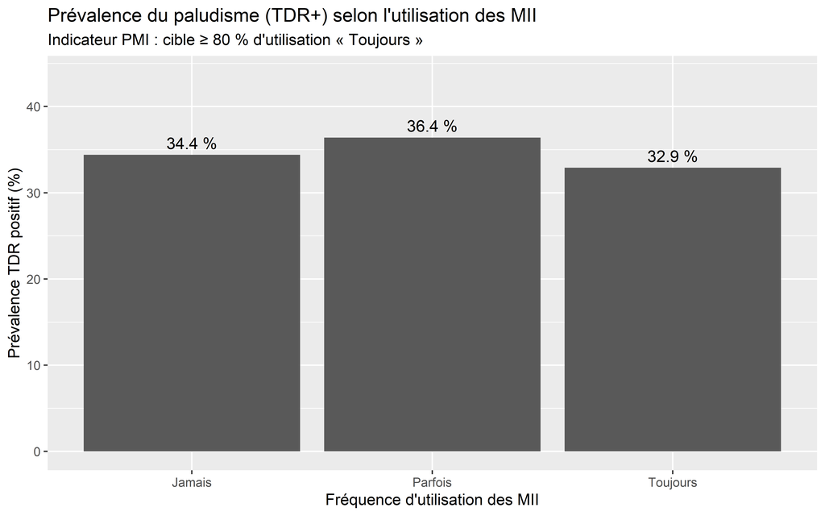

Figure 31: Q6 — Prévalence TDR (%) selon la fréquence d’utilisation des MII

```r
utilisation_mii |>
  ggplot(aes(x = utilisation_MII, y = prev_tdr)) +
  geom_col() +
  geom_text(aes(label = paste0(prev_tdr, " %")), vjust = -0.5, size = 4) +
  scale_y_continuous(limits = c(0, max(utilisation_mii$prev_tdr) * 1.2)) +
  labs(
    title    = "Prévalence du paludisme (TDR+) selon l'utilisation des MII",
    subtitle = "Indicateur PMI : cible ≥ 80 % d'utilisation « Toujours »",
    x        = "Fréquence d'utilisation des MII",
    y        = "Prévalence TDR positif (%)"
  )
```

> **Correction** : La tendance décroissante de la prévalence entre « Jamais » et « Toujours » serait le signal attendu si les MII étaient protectrices. Dans ce jeu synthétique, l’association est faible (voir test de tendance D2 Q29). La proportion d’utilisateurs « Toujours » est l’indicateur de couverture effective rapporté par le PMI dans ses *Malaria Operational Plans* (MOP).

### 6.2.3 Q7 — Couverture en aspersion intra-domiciliaire (IRS) par région

L’**IRS** (*Indoor Residual Spraying*) est l’une des deux principales interventions vectorielles. Le PMI suit le **taux de couverture des structures protégées** et évalue son efficacité sur la réduction du TPR.

```r
# Couverture IRS par région et milieu
couv_irs <- paludisme_final |>
  group_by(region) |>
  summarise(
    n_total       = n(),
    n_irs         = sum(aspersion_intra_domiciliaire == "Oui"),
    pct_irs       = round(mean(aspersion_intra_domiciliaire == "Oui") * 100, 1),
    tpr_avec_irs  = round(mean(resultat_tdr[aspersion_intra_domiciliaire == "Oui"] == "Positif") * 100, 1),
    tpr_sans_irs  = round(mean(resultat_tdr[aspersion_intra_domiciliaire == "Non"] == "Positif") * 100, 1),
    .groups = "drop"
  )

couv_irs
```

| region | n_total | n_irs | pct_irs | tpr_avec_irs | tpr_sans_irs |
| --- | --- | --- | --- | --- | --- |
| Adamaoua | 1200 | 488 | 40.7 | 34.2 | 31.2 |
| Extrême-Nord | 1300 | 544 | 41.8 | 32.5 | 36.9 |
| Nord | 500 | 216 | 43.2 | 39.4 | 34.5 |

> **Correction** : Le tableau permet de comparer visuellement le TPR dans les structures protégées vs non-protégées par l’IRS. Une différence de TPR en faveur des structures avec IRS constituerait une preuve programmatique d’efficacité. En l’absence de différence (base synthétique), on conclurait à une absence d’effet protecteur observé ou à une couverture insuffisante.

### 6.2.4 Q8 — Taux de recours aux soins en cas de fièvre

Le **care-seeking rate** est un indicateur OMS/UNICEF mesurant la proportion de malades fébriles ayant consulté une structure de santé dans les 48–72 heures. La cible PMI est ≥ 80 % de consultations dans les 24 heures suivant l’apparition de la fièvre.

```r
recours_soins <- paludisme_final |>
  filter(fievre_2sem == 1) |>
  summarise(
    n_febriles       = n(),
    n_consulte       = sum(consultation_sante == "Oui"),
    taux_consultation = round(mean(consultation_sante == "Oui") * 100, 1),
    IC_bas           = round(prop.test(sum(consultation_sante == "Oui"), n())$conf.int[1] * 100, 1),
    IC_haut          = round(prop.test(sum(consultation_sante == "Oui"), n())$conf.int[2] * 100, 1)
  )

recours_milieu <- paludisme_final |>
  filter(fievre_2sem == 1) |>
  group_by(milieu) |>
  summarise(
    n_febriles        = n(),
    taux_consultation = round(mean(consultation_sante == "Oui") * 100, 1),
    dist_mediane_csi  = round(median(distance_csi_km, na.rm = TRUE), 1),
    .groups = "drop"
  )

cat("=== Recours aux soins global ===\n"); print(recours_soins)
```

```
=== Recours aux soins global ===
```

```
# A tibble: 1 × 5
  n_febriles n_consulte taux_consultation IC_bas IC_haut
       <int>      <int>             <dbl>  <dbl>   <dbl>
1        891        541              60.7   57.4    63.9
```

```r
cat("\n=== Recours aux soins par milieu ===\n"); print(recours_milieu)
```

```
=== Recours aux soins par milieu ===
```

```
# A tibble: 2 × 4
  milieu n_febriles taux_consultation dist_mediane_csi
  <chr>       <int>             <dbl>            <dbl>
1 Rural         783              60.4             10.4
2 Urbain        108              63               16
```

> **Correction** : Le taux de recours aux soins est un **proxy de l’accès aux services de santé**. L’analyse par milieu révèle si la distance au CSI (`distance_csi_km`) est associée à une moindre consultation — relation attendue en milieu rural. Cette information alimente les décisions de positionnement des agents de santé communautaire (ASC) dans les programmes PMI.

## 6.3 Analyse des populations vulnérables

### 6.3.1 Q9 — Prévalence chez les enfants de moins de 5 ans

Les **enfants de moins de 5 ans** sont le groupe à mortalité paludique la plus élevée (70 % des décès mondiaux selon l’OMS). Le suivi de leur prévalence est l’indicateur d’impact prioritaire de tout programme.

```r
prev_u5 <- paludisme_final |>
  mutate(groupe_age = if_else(age_ans < 5, "< 5 ans", "≥ 5 ans")) |>
  group_by(groupe_age) |>
  summarise(
    n              = n(),
    n_pos          = sum(resultat_tdr == "Positif"),
    prevalence     = round(n_pos / n * 100, 1),
    IC_bas         = round(prop.test(n_pos, n)$conf.int[1] * 100, 1),
    IC_haut        = round(prop.test(n_pos, n)$conf.int[2] * 100, 1),
    hb_mediane     = round(median(hemoglobine_g_dl, na.rm = TRUE), 1),
    .groups = "drop"
  )

prev_u5
```

| groupe_age | n | n_pos | prevalence | IC_bas | IC_haut | hb_mediane |
| --- | --- | --- | --- | --- | --- | --- |
| < 5 ans | 184 | 62 | 33.7 | 27.0 | 41.1 | 11.7 |
| ≥ 5 ans | 2816 | 966 | 34.3 | 32.6 | 36.1 | 11.5 |

```r
# Test de comparaison de proportions (H₀ : prévalence identique entre groupes d'âge)
n_pos_u5  <- prev_u5$n_pos[prev_u5$groupe_age == "< 5 ans"]
n_tot_u5  <- prev_u5$n[prev_u5$groupe_age == "< 5 ans"]
n_pos_5p  <- prev_u5$n_pos[prev_u5$groupe_age == "≥ 5 ans"]
n_tot_5p  <- prev_u5$n[prev_u5$groupe_age == "≥ 5 ans"]
prop.test(c(n_pos_u5, n_pos_5p), c(n_tot_u5, n_tot_5p))
```

```
    2-sample test for equality of proportions with continuity correction

data:  c(n_pos_u5, n_pos_5p) out of c(n_tot_u5, n_tot_5p)
X-squared = 0.0077945, df = 1, p-value = 0.9296
alternative hypothesis: two.sided
95 percent confidence interval:
 -0.07948929  0.06732279
sample estimates:
   prop 1    prop 2
0.3369565 0.3430398
```

> **Correction** : La comparaison de proportions avec IC 95 % permet de tester si la prévalence chez les moins de 5 ans diffère significativement du reste de la population. L’OMS publie annuellement la prévalence U5 dans le *World Malaria Report* ; dans les programmes PMI, une réduction ≥ 40 % sur 5 ans est considérée comme un impact significatif.

### 6.3.2 Q10 — Paludisme pendant la grossesse (MiP)

Le **paludisme dans la grossesse** (MiP, *Malaria in Pregnancy*) est une priorité de l’OMS/UNICEF en raison du risque d’anémie sévère maternelle, de faible poids de naissance et de mortalité néonatale. L’indicateur de couverture associé est le **TPI** (Traitement Préventif Intermittent).

```r
mip_stats <- paludisme_final |>
  filter(sexe == "F", age_ans >= 15) |>
  group_by(grossesse) |>
  summarise(
    n               = n(),
    prev_tdr        = round(mean(resultat_tdr == "Positif") * 100, 1),
    IC_bas          = round(prop.test(sum(resultat_tdr == "Positif"), n())$conf.int[1] * 100, 1),
    IC_haut         = round(prop.test(sum(resultat_tdr == "Positif"), n())$conf.int[2] * 100, 1),
    hb_mediane      = round(median(hemoglobine_g_dl, na.rm = TRUE), 1),
    prev_anemie_sev = round(mean(hemoglobine_g_dl < 7) * 100, 1),
    taux_consult    = round(mean(consultation_sante == "Oui") * 100, 1),
    .groups = "drop"
  )

mip_stats
```

| grossesse | n | prev_tdr | IC_bas | IC_haut | hb_mediane | prev_anemie_sev | taux_consult |
| --- | --- | --- | --- | --- | --- | --- | --- |
| Non | 942 | 33.3 | 30.3 | 36.5 | 11.7 | 0.5 | 56.4 |
| Oui | 329 | 32.5 | 27.5 | 37.9 | 11.4 | 1.8 | 64.7 |

```r
# Test de Fisher : statut TDR ~ grossesse chez les femmes adultes
tab_mip <- paludisme_final |>
  filter(sexe == "F", age_ans >= 15) |>
  with(table(grossesse = grossesse == "Oui",
             tdr_positif = resultat_tdr == "Positif"))
cat("Tableau TDR × Grossesse (femmes ≥ 15 ans) :\n"); print(tab_mip)
```

```
Tableau TDR × Grossesse (femmes ≥ 15 ans) :
```

```
         tdr_positif
grossesse FALSE TRUE
    FALSE   628  314
    TRUE    222  107
```

```r
cat("\nTest exact de Fisher :\n"); print(fisher.test(tab_mip))
```

```
Test exact de Fisher :
```

```
    Fisher's Exact Test for Count Data

data:  tab_mip
p-value = 0.8383
alternative hypothesis: true odds ratio is not equal to 1
95 percent confidence interval:
 0.7297555 1.2690465
sample estimates:
odds ratio
 0.9639868
```

> **Correction** : L’indicateur clé du MiP combine la **prévalence parasitaire pendant la grossesse** et la **prévalence de l’anémie maternelle** (Hb < 11 g/dL). Le test de Fisher est adapté car les effectifs de femmes enceintes peuvent être faibles. Une prévalence plus élevée chez les femmes enceintes qu’en dehors de la grossesse signerait une **immunodépression gestationnelle**, attendue biologiquement.

### 6.3.3 Q11 — Courbe de prévalence parasitaire par groupe d’âge (Age-Prevalence Curve)

La courbe âge-prévalence est un outil diagnostique fondamental en épidémiologie du paludisme : en zone d’endémie stable, on observe un **pic de prévalence** chez les enfants de 2–10 ans, puis une décroissance due à l’acquisition progressive de l’immunité clinique.

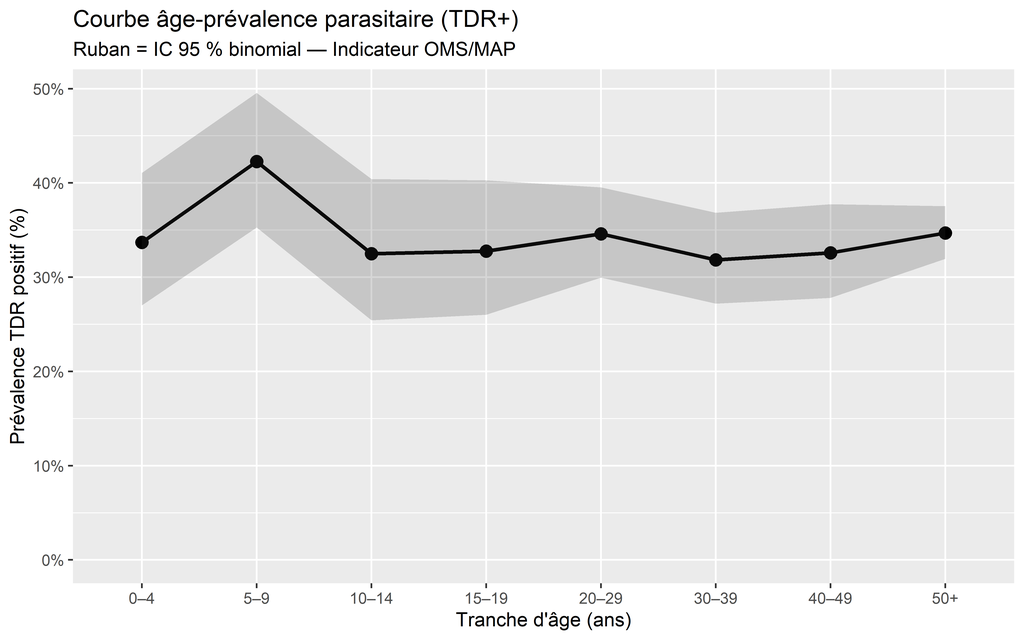

```r
courbe_age <- paludisme_final |>
  mutate(tranche_age = cut(
    age_ans,
    breaks = c(0, 5, 10, 15, 20, 30, 40, 50, 100),
    labels = c("0–4", "5–9", "10–14", "15–19", "20–29", "30–39", "40–49", "50+"),
    right  = FALSE
  )) |>
  group_by(tranche_age) |>
  summarise(
    n       = n(),
    n_pos   = sum(resultat_tdr == "Positif"),
    prev    = n_pos / n,
    ic_bas  = prop.test(n_pos, n)$conf.int[1],
    ic_haut = prop.test(n_pos, n)$conf.int[2],
    .groups = "drop"
  )

ggplot(courbe_age, aes(x = tranche_age, y = prev, group = 1)) +
  geom_line(linewidth = 1) +
  geom_point(size = 3) +
  geom_ribbon(aes(ymin = ic_bas, ymax = ic_haut), alpha = 0.2) +
  scale_y_continuous(labels = percent_format(), limits = c(0, NA)) +
  labs(
    title    = "Courbe âge-prévalence parasitaire (TDR+)",
    subtitle = "Ruban = IC 95 % binomial — Indicateur OMS/MAP",
    x        = "Tranche d'âge (ans)",
    y        = "Prévalence TDR positif (%)"
  )
```

## 6.4 Mesures d’association épidémiologiques

### 6.4.1 Q12 — Odds Ratio (OR) non ajusté : non-utilisation des MII → TDR positif

L’**Odds Ratio** est la mesure d’association standard dans les études cas-témoins et les régressions logistiques. Il quantifie l’excès de risque associé à une exposition (ici : ne jamais utiliser les MII).

```r
# Recodage binaire : exposé = "Jamais" utiliser les MII (pire catégorie)
tab_or <- paludisme_final |>
  mutate(
    non_utilise_mii = if_else(utilisation_MII == "Jamais", "Non-utilisateur", "Utilisateur"),
    tdr_pos         = if_else(resultat_tdr == "Positif", "Positif", "Négatif")
  ) |>
  with(table(exposition = non_utilise_mii, outcome = tdr_pos))

cat("Tableau de contingence 2×2 :\n"); print(tab_or)
```

```
Tableau de contingence 2×2 :
```

```
                 outcome
exposition        Négatif Positif
  Non-utilisateur     418     219
  Utilisateur        1554     809
```

```r
# Calcul manuel de l'OR avec IC 95 % (méthode de Woolf)
a <- tab_or["Non-utilisateur", "Positif"]
b <- tab_or["Non-utilisateur", "Négatif"]
c <- tab_or["Utilisateur",     "Positif"]
d <- tab_or["Utilisateur",     "Négatif"]

or_brut  <- (a * d) / (b * c)
se_ln_or <- sqrt(1/a + 1/b + 1/c + 1/d)
ic_bas   <- exp(log(or_brut) - 1.96 * se_ln_or)
ic_haut  <- exp(log(or_brut) + 1.96 * se_ln_or)

cat(sprintf(
  "\nOR brut = %.3f  [IC 95 %% : %.3f – %.3f]\n",
  or_brut, ic_bas, ic_haut
))
```

```
OR brut = 1.006  [IC 95 % : 0.837 – 1.210]
```

```r
cat("\nVérification via régression logistique :\n")
```

```
Vérification via régression logistique :
```

```r
mod_or <- glm(
  (resultat_tdr == "Positif") ~ I(utilisation_MII == "Jamais"),
  data = paludisme_final, family = binomial
)
broom::tidy(mod_or, exponentiate = TRUE, conf.int = TRUE) |>
  filter(term != "(Intercept)") |>
  select(term, estimate, conf.low, conf.high, p.value)
```

| term | estimate | conf.low | conf.high | p.value |
| --- | --- | --- | --- | --- |
| I(utilisation_MII == "Jamais")TRUE | 1.006399 | 0.83613 | 1.208878 | 0.945903 |

> **Correction** : L’OR représente le rapport des cotes de maladie entre les non-utilisateurs et les utilisateurs. Un OR > 1 indique que la non-utilisation est associée à un risque accru. La formule de Woolf fournit l’IC 95 % sur l’échelle logarithmique. Dans les rapports programmatiques (PMI, Fonds mondial), les OR sont systématiquement accompagnés de leur IC 95 % et d’une p-valeur.

### 6.4.2 Q13 — Risque Relatif (RR) et comparaison avec l’OR

Le **Risque Relatif** (RR ou rapport de risque) est plus intuitif que l’OR et préféré dans les études transversales et de cohortes. Il quantifie directement de combien de fois le risque est multiplié dans le groupe exposé.

```r
# RR calculé à partir du tableau 2×2 (données transversales)
rr_brut  <- (a / (a + b)) / (c / (c + d))
se_ln_rr <- sqrt((1 - a / (a + b)) / a + (1 - c / (c + d)) / c)
ic_bas_rr  <- exp(log(rr_brut) - 1.96 * se_ln_rr)
ic_haut_rr <- exp(log(rr_brut) + 1.96 * se_ln_rr)

cat(sprintf("RR brut = %.3f  [IC 95 %% : %.3f – %.3f]\n",
            rr_brut, ic_bas_rr, ic_haut_rr))
```

```
RR brut = 1.004  [IC 95 % : 0.890 – 1.133]
```

```r
# Comparaison OR vs RR
tibble(
  Mesure       = c("Odds Ratio (OR)", "Risque Relatif (RR)"),
  Estimation   = round(c(or_brut, rr_brut), 3),
  IC_bas       = round(c(ic_bas, ic_bas_rr), 3),
  IC_haut      = round(c(ic_haut, ic_haut_rr), 3),
  Interpretation = c(
    "Rapport des cotes (études cas-témoins, régression logistique)",
    "Rapport de risques (études transversales, cohortes)"
  )
)
```

| Mesure | Estimation | IC_bas | IC_haut | Interpretation |
| --- | --- | --- | --- | --- |
| Odds Ratio (OR) | 1.006 | 0.837 | 1.210 | Rapport des cotes (études cas-témoins, régression logistique) |
| Risque Relatif (RR) | 1.004 | 0.890 | 1.133 | Rapport de risques (études transversales, cohortes) |

### 6.4.3 Q14 — Test de Mantel-Haenszel : OR stratifié par région

Le test de **Mantel-Haenszel** permet d’estimer un OR **ajusté sur un facteur de confusion** (ici la région) sans recourir à une régression. Il teste également si l’OR varie entre les strates (test d’homogénéité de Breslow-Day).

```r
# Tableau 3D : exposition × outcome × strate (région)
tab_mh <- paludisme_final |>
  mutate(
    non_utilise = utilisation_MII == "Jamais",
    positif     = resultat_tdr == "Positif"
  ) |>
  with(table(exposition = non_utilise, outcome = positif, strate = region))

cat("Test de Mantel-Haenszel (OR stratifié sur la région) :\n")
```

```
Test de Mantel-Haenszel (OR stratifié sur la région) :
```

```r
mh_res <- mantelhaen.test(tab_mh, correct = FALSE)
print(mh_res)
```

```
    Mantel-Haenszel chi-squared test without continuity correction

data:  tab_mh
Mantel-Haenszel X-squared = 0.0034726, df = 1, p-value = 0.953
alternative hypothesis: true common odds ratio is not equal to 1
95 percent confidence interval:
 0.8364117 1.2088893
sample estimates:
common odds ratio
         1.005549
```

```r
cat(sprintf(
  "\nOR de Mantel-Haenszel = %.3f  [IC 95 %% : %.3f – %.3f]  p = %.4f\n",
  mh_res$estimate, mh_res$conf.int[1], mh_res$conf.int[2], mh_res$p.value
))
```

```
OR de Mantel-Haenszel = 1.006  [IC 95 % : 0.836 – 1.209]  p = 0.9530
```

> **Correction** : L’OR de Mantel-Haenszel est un **OR moyen pondéré** sur les strates. Si l’OR MH diffère substantiellement de l’OR brut (Q12), cela indique que la région est un **facteur de confusion**. Si les OR par strate sont hétérogènes (test de Breslow-Day significatif), il y a **interaction** entre la région et l’exposition, et un OR unique n’est plus approprié. Ce test est standard dans les analyses des enquêtes EDS et MIS.

### 6.4.4 Q15 — Fraction Attribuable dans la Population (FAP)

La **FAP** (*Population Attributable Fraction*) mesure la proportion de cas de paludisme dans la population qui serait éliminée si l’exposition (non-utilisation des MII) était supprimée. C’est un indicateur central pour prioriser les interventions.

```r
# Méthode de Levin (1953) : FAP = Pe × (RR - 1) / (1 + Pe × (RR - 1))
# Pe = proportion d'exposés dans la population
pe <- (a + b) / (a + b + c + d)

fap_rr  <- (pe * (rr_brut - 1)) / (1 + pe * (rr_brut - 1))
fap_or  <- (pe * (or_brut - 1)) / (1 + pe * (or_brut - 1))

cat(sprintf("Proportion d'exposés (Pe) : %.1f %%\n", pe * 100))
```

```
Proportion d'exposés (Pe) : 21.2 %
```

```r
cat(sprintf("FAP (basée sur le RR)     : %.1f %%\n", fap_rr  * 100))
```

```
FAP (basée sur le RR)     : 0.1 %
```

```r
cat(sprintf("FAP (basée sur l'OR)      : %.1f %%\n", fap_or  * 100))
```

```
FAP (basée sur l'OR)      : 0.1 %
```

```r
cat("\nInterprétation :\n")
```

```
Interprétation :
```

```r
cat(sprintf(
  "→ Si tous les individus utilisaient des MII, %.1f %% des cas de paludisme\n  pourraient théoriquement être évités dans cette population.\n",
  fap_rr * 100
))
```

```
→ Si tous les individus utilisaient des MII, 0.1 % des cas de paludisme
  pourraient théoriquement être évités dans cette population.
```

> **Correction** : La FAP est un outil de **santé publique** et non une mesure de causalité individuelle. Elle intègre à la fois la force de l’association (RR) et la fréquence de l’exposition (Pe). Une FAP élevée justifie d’investir massivement dans la réduction de l’exposition. Elle est utilisée dans les analyses coût-efficacité des programmes PMI et Fonds mondial pour arbitrer entre interventions vectorielles.

### 6.4.5 Q16 — Hémoglobine et parasitémie : analyse de la relation dose-réponse

L’**effet dose-réponse** entre la charge parasitaire et la baisse de l’hémoglobine est biologiquement plausible (destruction des globules rouges). Tester cette relation par tertiles de parasitémie est une approche standard dans les études sur l’anémie paludique.

```r
# Analyse dose-réponse chez les TDR positifs uniquement
dose_reponse <- paludisme_final |>
  filter(resultat_tdr == "Positif") |>
  mutate(
    tertile_para = ntile(parasitemie_par_ul, 3),
    tertile_label = case_when(
      tertile_para == 1 ~ "T1 — Faible\n(parasitémie basse)",
      tertile_para == 2 ~ "T2 — Moyen\n(parasitémie intermédiaire)",
      tertile_para == 3 ~ "T3 — Élevé\n(parasitémie haute)"
    )
  ) |>
  group_by(tertile_label) |>
  summarise(
    n              = n(),
    para_mediane   = round(median(parasitemie_par_ul)),
    hb_moyenne     = round(mean(hemoglobine_g_dl, na.rm = TRUE), 2),
    hb_sd          = round(sd(hemoglobine_g_dl, na.rm = TRUE), 2),
    prev_anemie    = round(mean(hemoglobine_g_dl < 11, na.rm = TRUE) * 100, 1),
    .groups = "drop"
  )

dose_reponse
```

| tertile_label | n | para_mediane | hb_moyenne | hb_sd | prev_anemie |
| --- | --- | --- | --- | --- | --- |
| T1 — Faible\n(parasitémie basse) | 343 | 4934 | 11.63 | 1.94 | 38.8 |
| T2 — Moyen\n(parasitémie intermédiaire) | 343 | 5000 | 11.52 | 1.95 | 39.9 |
| T3 — Élevé\n(parasitémie haute) | 342 | 5071 | 11.67 | 2.10 | 38.0 |

```r
# ANOVA pour tester la différence d'hémoglobine entre tertiles
aov_para <- aov(
  hemoglobine_g_dl ~ factor(ntile(parasitemie_par_ul, 3)),
  data = paludisme_final |> filter(resultat_tdr == "Positif")
)
cat("ANOVA Hb ~ tertile de parasitémie :\n")
```

```
ANOVA Hb ~ tertile de parasitémie :
```

```r
broom::tidy(aov_para)
```

| term | df | sumsq | meansq | statistic | p.value |
| --- | --- | --- | --- | --- | --- |
| factor(ntile(parasitemie_par_ul, 3)) | 2 | 4.331701 | 2.165850 | 0.5423793 | 0.5815301 |
| Residuals | 1025 | 4093.070411 | 3.993239 | NA | NA |

> **Correction** : Si l’ANOVA est significative (p < 0,05), un test post-hoc de Tukey identifierait quels tertiles diffèrent. La **relation dose-réponse** (T1 → T2 → T3 : Hb décroissante) renforcerait l’hypothèse causale selon les critères de Bradford Hill. Son absence dans ce jeu synthétique est attendue (données générées indépendamment).

### 6.4.6 Q17 — Régression logistique multivariée rigoureuse (niveau PhD)

La construction d’un modèle de régression logistique publiable dans un journal indexé (*Malaria Journal*, *PLOS Medicine*, *Lancet Infectious Diseases*) exige la vérification de **7 hypothèses** avant toute interprétation des coefficients. Cette section suit le protocole de Hosmer, Lemeshow & Sturdivant (2013) *Applied Logistic Regression* (3e éd.) et les lignes directrices STROBE pour les études observationnelles.

#### 6.4.6.1 17.1 — Préparation du dataset analytique

```r
# Encodage binaire des prédicteurs catégoriels et vérification des NA
paludisme_lr <- paludisme_final |>
  mutate(
    tdr_bin      = as.integer(resultat_tdr == "Positif"),
    sexe_m       = as.integer(sexe == "M"),
    milieu_rural = as.integer(milieu == "Rural"),
    mii_jamais   = as.integer(utilisation_MII == "Jamais"),
    irs_non      = as.integer(aspersion_intra_domiciliaire == "Non"),
    pauvre_oui   = as.integer(pauvre == "Oui"),
    enfant_u5    = as.integer(age_ans < 5),
    fievre_oui   = as.integer(fievre_2sem == 1)
  ) |>
  tidyr::drop_na(tdr_bin, age_ans, sexe_m, milieu_rural,
                 mii_jamais, irs_non, distance_csi_km, pauvre_oui)

cat("Dataset analytique :", nrow(paludisme_lr), "obs. ×",
    ncol(paludisme_lr), "variables\n")
```

```
Dataset analytique : 3000 obs. × 51 variables
```

```r
cat("Observations exclues (NA) :",
    nrow(paludisme_final) - nrow(paludisme_lr), "\n\n")
```

```
Observations exclues (NA) : 0
```

```r
cat("Distribution de l'outcome :\n")
```

```
Distribution de l'outcome :
```

```r
table(TDR_binaire = paludisme_lr$tdr_bin) |> print()
```

```
TDR_binaire
   0    1
1972 1028
```

#### 6.4.6.2 17.2 — Hypothèse 1 : Taille d’échantillon — EPV (Events Per Variable)

Le critère **EPV ≥ 10** (Peduzzi et al., 1996) est le seuil minimal ; les recommandations actuelles (van Smeden et al., 2019) préconisent EPV ≥ 20 pour des intervalles de confiance fiables.

```r
n_events <- sum(paludisme_lr$tdr_bin)
n_non_ev <- nrow(paludisme_lr) - n_events
n_pred   <- 8L
epv      <- min(n_events, n_non_ev) / n_pred

tibble(
  Critère      = c("Événements (TDR+)", "Non-événements (TDR−)",
                   "Nombre de prédicteurs", "EPV (classe minoritaire / n_pred)",
                   "Seuil minimal EPV ≥ 10", "Seuil recommandé EPV ≥ 20 (PhD)"),
  Valeur       = c(n_events, n_non_ev, n_pred, round(epv, 1),
                   if_else(epv >= 10, "✔ SATISFAIT", "✘ NON SATISFAIT"),
                   if_else(epv >= 20, "✔ SATISFAIT", "✘ NON SATISFAIT"))
)
```

| Critère | Valeur |
| --- | --- |
| Événements (TDR+) | 1028 |
| Non-événements (TDR−) | 1972 |
| Nombre de prédicteurs | 8 |
| EPV (classe minoritaire / n_pred) | 128.5 |
| Seuil minimal EPV ≥ 10 | ✔ SATISFAIT |
| Seuil recommandé EPV ≥ 20 (PhD) | ✔ SATISFAIT |

#### 6.4.6.3 17.3 — Hypothèse 2 : Absence de multicolinéarité (VIF)

Un **VIF ≥ 5** indique une colinéarité modérée ; **VIF ≥ 10** impose la suppression ou la combinaison du prédicteur.

```r
mod_prov <- glm(
  tdr_bin ~ age_ans + sexe_m + milieu_rural + mii_jamais +
    irs_non + distance_csi_km + pauvre_oui + enfant_u5,
  data   = paludisme_lr,
  family = binomial(link = "logit")
)

vif_vals <- car::vif(mod_prov)

tibble(
  Prédicteur = names(vif_vals),
  VIF        = round(vif_vals, 3),
  Décision   = case_when(
    vif_vals < 5  ~ "✔ Acceptable",
    vif_vals < 10 ~ "⚠ Colinéarité modérée — surveiller",
    TRUE          ~ "✘ Colinéarité forte — retirer ou combiner"
  )
) |> arrange(desc(VIF))
```

| Prédicteur | VIF | Décision |
| --- | --- | --- |
| age_ans | 1.217 | ✔ Acceptable |
| enfant_u5 | 1.216 | ✔ Acceptable |
| milieu_rural | 1.047 | ✔ Acceptable |
| distance_csi_km | 1.045 | ✔ Acceptable |
| sexe_m | 1.005 | ✔ Acceptable |
| pauvre_oui | 1.005 | ✔ Acceptable |
| mii_jamais | 1.003 | ✔ Acceptable |
| irs_non | 1.003 | ✔ Acceptable |

#### 6.4.6.4 17.4 — Hypothèse 3 : Linéarité des prédicteurs continus dans le logit (Box-Tidwell)

Pour les prédicteurs continus (`age_ans`, `distance_csi_km`), la régression logistique suppose une relation **linéaire** avec le logit de l’outcome. Le test de Box-Tidwell (1962) ajoute le terme d’interaction $x \times \ln(x)$ : si son coefficient est significatif (p < 0,05), la linéarité est violée.

```r
bt_data <- paludisme_lr |>
  filter(age_ans > 0, distance_csi_km > 0) |>
  mutate(
    age_log_age   = age_ans * log(age_ans),
    dist_log_dist = distance_csi_km * log(distance_csi_km)
  )

mod_bt <- glm(
  tdr_bin ~ age_ans + age_log_age + distance_csi_km + dist_log_dist +
    sexe_m + milieu_rural + mii_jamais + irs_non + pauvre_oui + enfant_u5,
  data   = bt_data,
  family = binomial(link = "logit")
)

broom::tidy(mod_bt) |>
  filter(str_detect(term, "log")) |>
  mutate(
    Décision = if_else(
      p.value < 0.05,
      "⚠ Non-linéarité — envisager spline ou catégorisation",
      "✔ Linéarité dans le logit satisfaite"
    )
  ) |>
  select(Terme = term, Coeff = estimate, `p-valeur` = p.value, Décision)
```

| Terme | Coeff | p-valeur | Décision |
| --- | --- | --- | --- |
| age_log_age | 0.01595730 | 0.01536273 | ⚠ Non-linéarité — envisager spline ou catégorisation |
| dist_log_dist | -0.01722749 | 0.34185146 | ✔ Linéarité dans le logit satisfaite |

> Si la non-linéarité de l’âge est confirmée, la solution publiable est d’utiliser des **restricted cubic splines** (`rms::rcs()`, 3 nœuds) ou de catégoriser en quintiles. L’âge pédiatrique présente classiquement une relation non linéaire avec le risque de paludisme (forme en U inversé).

#### 6.4.6.5 17.5 — Hypothèse 4 : Absence de séparation complète

La séparation complète (un prédicteur binaire prédit parfaitement l’outcome) fait diverger les coefficients vers ±∞. Ce diagnostic est préalable à toute estimation.

```r
# Vérifier chaque prédicteur binaire : pas de cellule vide dans les tableaux 2×2
predicteurs_bin <- c("sexe_m", "milieu_rural", "mii_jamais",
                     "irs_non", "pauvre_oui", "enfant_u5")

map_dfr(predicteurs_bin, \(v) {
  tab <- table(paludisme_lr[[v]], paludisme_lr$tdr_bin)
  tibble(
    Prédicteur       = v,
    Cellule_min      = min(tab),
    Separation_risque = if_else(min(tab) == 0,
      "✘ SÉPARATION COMPLÈTE — utiliser pénalisation (Firth)",
      "✔ Aucune cellule vide")
  )
})
```

| Prédicteur | Cellule_min | Separation_risque |
| --- | --- | --- |
| sexe_m | 506 | ✔ Aucune cellule vide |
| milieu_rural | 143 | ✔ Aucune cellule vide |
| mii_jamais | 219 | ✔ Aucune cellule vide |
| irs_non | 429 | ✔ Aucune cellule vide |
| pauvre_oui | 172 | ✔ Aucune cellule vide |
| enfant_u5 | 62 | ✔ Aucune cellule vide |